# Tarea 1 - Herramientas de Pronóstico y Métodos de Suavizamiento

Autor/a

Esteban Daza Palomino

Fecha de publicación

25 de septiembre de 2026

## Introducción

Este informe presenta el análisis de los ocho métodos de pronóstico univariado de la tarea y un contraejemplo en el que el patrón de la serie contradice el supuesto del método. Todo el cálculo lo hace `ejemplos/ejemplos.R`, que carga las funciones de la carpeta `R/` y guarda sus resultados en la lista `resultados`; las cifras de este documento se toman directamente de esa lista, de modo que coinciden siempre con la ejecución.

Cada ejemplo sigue el mismo protocolo: descripción de la serie con cifras verificadas por código; gráfico, correlograma, contraste individual de las autocorrelaciones y prueba de Ljung-Box sobre la serie; partición en un tramo de estimación y un tramo de validación con las últimas $h = \min\{12, \lfloor 0.2T \rfloor\}$ observaciones; ajuste con los parámetros elegidos por `optimizar()`; medidas MSE, MAD, MAPE y MASE; validación de los errores de un paso; y gráfico final con la serie, el ajuste y los pronósticos.

Tres convenciones se mantienen en todos los ejemplos:

- **Referente.** Cada método se compara, sobre el mismo tramo de validación y con el mismo $h$, contra el pronóstico ingenuo $\hat Y_{T+h} = Y_T$, o contra el ingenuo estacional cuando la serie es estacional. El MASE divide el MAD del método entre el MAD del ingenuo de un paso dentro del tramo de estimación. Por eso un MASE mayor que 1 en validación no significa necesariamente que el método pierda contra el referente: en validación se pronostica hasta $h$ pasos adelante, lo cual es más difícil que el pronóstico de un paso con el que se escala. La comparación directa contra el referente se hace con el MAD de ambos en el tramo de validación.
- **Parámetros estimados.** En la prueba de Ljung-Box sobre los errores, $p$ es el número de parámetros estimados con los datos: 0 en la media simple, 1 en la media móvil y en la doble media móvil (la ventana $k$ se elige con `optimizar()`), 1 en el suavizamiento exponencial simple, 2 en Holt y el número de coeficientes en las tendencias.
- **Durbin-Watson.** En las tendencias, que son regresiones, se decide con las cotas $d_L$ y $d_U$ de Savin y White (1977). En los demás métodos no hay matriz de regresores y esas cotas no aplican, así que se usa la aproximación asintótica $z = (2-d)\sqrt{N}/2 \approx N(0,1)$.

## 1. Media Simple

```r
ejecutar_protocolo("discoveries", datasets::discoveries,
                   "The World Almanac and Book of Facts, 1975 Edition, pages 315-318",
                   "Numero de descubrimientos", "ajustar_media", "Media Simple",
                   p_params = 0, prefijo = "01")
```

### Descripción de la serie

```r
ej <- resultados$ej01
c(N = ej$N, frecuencia = ej$frecuencia)
```

```
         N frecuencia
       100          1
```

```r
c(inicio = ej$fecha_ini, fin = ej$fecha_fin)
```

```
      inicio          fin
"1860-01-01" "1959-01-01"
```

La serie `discoveries` registra el número de grandes inventos y descubrimientos científicos por año. Fuente: The World Almanac and Book of Facts, 1975 Edition, pages 315-318. Unidad: numero de descubrimientos. Frecuencia anual, de 1860 a 1959, con $N = 100$ observaciones.

### Patrón de la serie

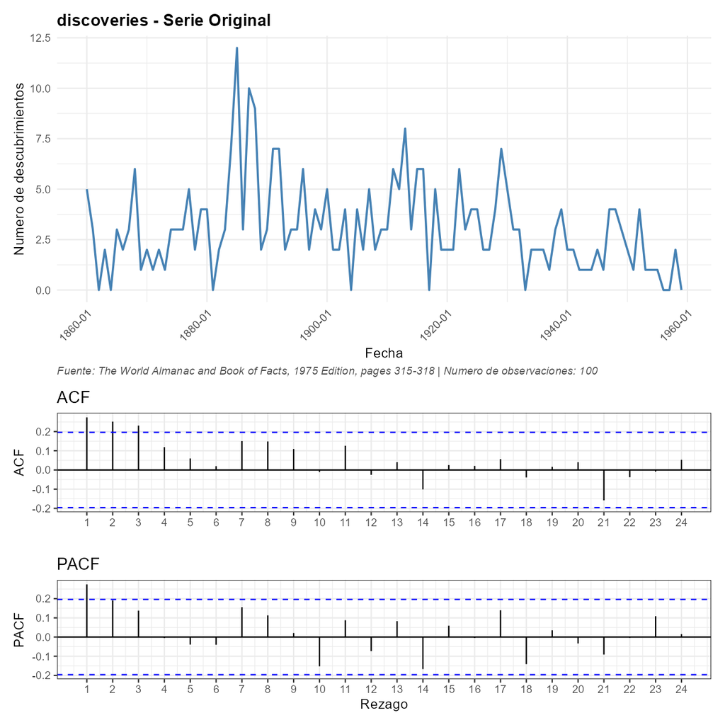

discoveries: serie original, ACF y PACF

La serie oscila alrededor de un nivel de unos tres descubrimientos por año, sin tendencia sostenida ni patrón estacional. El supuesto de la media simple es justamente ese: un nivel constante al que se suma ruido.

**Contraste individual de las autocorrelaciones de la serie**

1. *Hipótesis:* para cada rezago $h = 1, \ldots, 24$, $H_0: \rho_h = 0$ frente a $H_1: \rho_h \neq 0$.
2. *Estadístico:* $r_h = c_h / c_0$, con $c_h = n^{-1}\sum_{t=1}^{n-h}(x_t - \bar x)(x_{t+h} - \bar x)$. Por el resultado de Bartlett, bajo ruido blanco $r_h \approx N(0, 1/n)$, con $n = 100$.
3. *Región de rechazo al 5%:* $|r_h| > z_{0.975}/\sqrt{n} = 1.96/\sqrt{100} = 0.1960$.
4. *Valores observados:* la tabla muestra $r_h$, $z = r_h\sqrt{n}$ y su valor p en los rezagos que sostienen la lectura.
5. *Decisión:* se rechaza $H_0$ en los rezagos 1, 2, 3 y no se rechaza en los demás de los 24 examinados.
6. *Lectura:* la dependencia es débil y de corto alcance: solo los primeros rezagos superan la banda y su magnitud es moderada. No aparece el decaimiento lento que produciría una tendencia ni picos periódicos que indiquen estacionalidad.

| Rezago $h$ | $r_h$ | $z$ | Valor p | Decisión |
| --- | --- | --- | --- | --- |
| 1 | 0.2741 | 2.741 | 0.0061 | Se rechaza |
| 2 | 0.2520 | 2.520 | 0.0117 | Se rechaza |
| 3 | 0.2310 | 2.310 | 0.0209 | Se rechaza |

**Prueba de Ljung-Box sobre la serie**

1. *Hipótesis:* $H_0: \rho_1 = \cdots = \rho_{24} = 0$ frente a $H_1$: al menos un $\rho_h \neq 0$ con $h \le 24$.
2. *Estadístico:* $Q_m = T(T+2)\sum_{h=1}^{m} r_h^2/(T-h)$, con $T = 100$ y $m = 24$. Bajo $H_0$, $Q_m \sim \chi^2_{m-p}$, con $p = 0$ parámetros estimados, es decir $\chi^2_{24}$.
3. *Región de rechazo al 5%:* $Q_m > \chi^2_{0.95;\,24} = 36.415$.
4. *Valor observado:* $Q_m = 36.254$, valor p $= 0.0518$.
5. *Decisión:* No se rechaza $H_0$ al 5%.
6. *Lectura:* tomadas en conjunto, las autocorrelaciones hasta el rezago 24 no son distinguibles de cero al 5%, aunque por muy poco. La serie es compatible con un nivel constante más ruido, que es el supuesto de la media simple.

### Partición y ajuste

Con $T = 100$, el tramo de validación son las últimas $h = 12$ observaciones y el ajuste usa las primeras 88. La media simple no tiene constantes que elegir, así que no requiere `optimizar()`. Su pronóstico es la media de todo el tramo de estimación, $\bar Y_T = 3.307$ descubrimientos por año.

### Medidas de precisión

```r
round(rbind(metodo_estimacion    = ej$medidas_in,
            metodo_validacion    = ej$medidas_out,
            referente_validacion = ej$medidas_referente_out), 4)
```

```
                        MSE    MAD MAPE   MASE
metodo_estimacion    5.4246 1.7663  Inf 0.8306
metodo_validacion    4.8801 1.9545  Inf 0.9192
referente_validacion 7.7500 2.4167  Inf 1.1365
```

En el tramo de validación, la media simple obtiene un MAD de 1.955 frente a 2.417 del ingenuo, es decir, un error 19.1% menor. El MASE es 0.919. El MAPE es infinito porque la serie tiene años con cero descubrimientos, en los que el error porcentual no está definido.

### Validación de errores

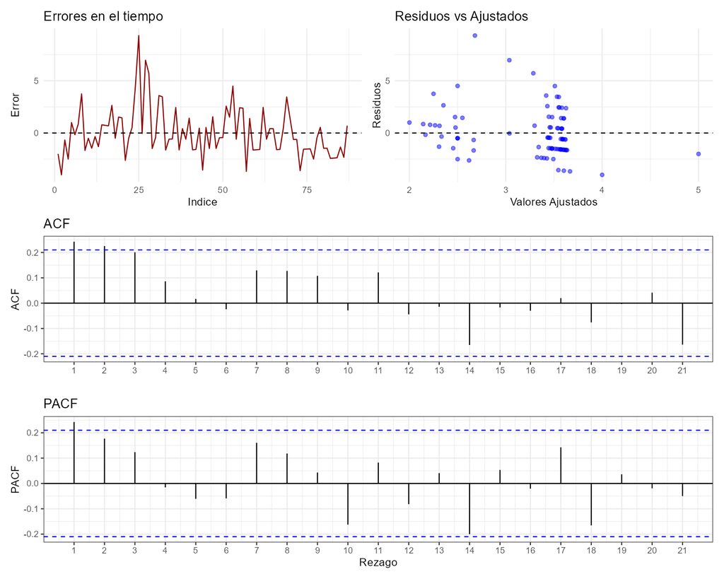

Media Simple: diagnóstico de los errores

**Contraste individual de las autocorrelaciones de los errores**

1. *Hipótesis:* para cada rezago $h = 1, \ldots, 21$, $H_0: \rho_h = 0$ frente a $H_1: \rho_h \neq 0$.
2. *Estadístico:* $r_h = c_h / c_0$, con $c_h = n^{-1}\sum_{t=1}^{n-h}(x_t - \bar x)(x_{t+h} - \bar x)$. Por el resultado de Bartlett, bajo ruido blanco $r_h \approx N(0, 1/n)$, con $n = 87$.
3. *Región de rechazo al 5%:* $|r_h| > z_{0.975}/\sqrt{n} = 1.96/\sqrt{87} = 0.2101$.
4. *Valores observados:* la tabla muestra $r_h$, $z = r_h\sqrt{n}$ y su valor p en los rezagos que sostienen la lectura.
5. *Decisión:* se rechaza $H_0$ en los rezagos 1, 2 y no se rechaza en los demás de los 21 examinados.
6. *Lectura:* quedan autocorrelaciones positivas en los primeros rezagos: cuando un año tiene muchos descubrimientos, el siguiente tiende a tenerlos también, y la media de todo el pasado no sigue esas rachas.

| Rezago $h$ | $r_h$ | $z$ | Valor p | Decisión |
| --- | --- | --- | --- | --- |
| 1 | 0.2426 | 2.263 | 0.0236 | Se rechaza |
| 2 | 0.2254 | 2.102 | 0.0355 | Se rechaza |

**Prueba t de media cero de los errores** ($N = 87$ errores)

1. *Hipótesis:* $H_0: \mu_e = 0$ frente a $H_1: \mu_e \neq 0$.
2. *Estadístico:* $t = \sqrt{N}\,\bar e / s_e$. Bajo $H_0$, $t \sim t_{N-1} = t_{86}$.
3. *Región de rechazo al 5%:* $|t| > t_{0.975;\,86} = 1.988$.
4. *Valor observado:* $t = 0.194$, valor p $= 0.8464$.
5. *Decisión:* No se rechaza $H_0$ al 5%.
6. *Lectura:* los errores no están sesgados: en promedio, la media simple no sobreestima ni subestima el número de descubrimientos.

**Prueba de Ljung-Box sobre los errores**

1. *Hipótesis:* $H_0: \rho_1 = \cdots = \rho_{21} = 0$ frente a $H_1$: al menos un $\rho_h \neq 0$ con $h \le 21$.
2. *Estadístico:* $Q_m = T(T+2)\sum_{h=1}^{m} r_h^2/(T-h)$, con $T = 87$ y $m = 21$. Bajo $H_0$, $Q_m \sim \chi^2_{m-p}$, con $p = 0$ parámetros estimados, es decir $\chi^2_{21}$.
3. *Región de rechazo al 5%:* $Q_m > \chi^2_{0.95;\,21} = 32.671$.
4. *Valor observado:* $Q_m = 27.643$, valor p $= 0.1506$.
5. *Decisión:* No se rechaza $H_0$ al 5%.
6. *Lectura:* en conjunto, los errores no muestran autocorrelación significativa; la dependencia de corto plazo que se ve en los primeros rezagos no alcanza para rechazar la independencia global.

**Prueba de Jarque-Bera** ($N = 87$ errores)

1. *Hipótesis:* $H_0$: los errores son normales ($A = 0$ y $K = 3$) frente a $H_1$: no son normales.
2. *Estadístico:* $JB = \frac{N}{6}\left[A^2 + \frac{(K-3)^2}{4}\right]$, con asimetría $A = 1.231$ y curtosis $K = 5.307$. Bajo $H_0$, $JB \sim \chi^2_2$ de forma asintótica.
3. *Región de rechazo al 5%:* $JB > \chi^2_{0.95;\,2} = 5.991$.
4. *Valor observado:* $JB = 41.267$, valor p $< 0.0001$.
5. *Decisión:* Se rechaza $H_0$ al 5%.
6. *Lectura:* los errores no son normales: tienen asimetría positiva y colas pesadas, como corresponde a un conteo con años excepcionales de muchos descubrimientos.

**Prueba de Durbin-Watson** ($N = 87$ errores)

1. *Hipótesis:* $H_0: \rho_1 = 0$ frente a $H_1: \rho_1 \neq 0$.
2. *Estadístico:* $d = \sum_{t=2}^{N}(e_t - e_{t-1})^2 / \sum_{t=1}^{N} e_t^2 \approx 2(1 - r_1)$. Las cotas $d_L$ y $d_U$ solo aplican a residuos de una regresión; para los errores de un método se usa que, bajo $H_0$, $r_1 \approx N(0, 1/N)$, de modo que $z = (2 - d)\sqrt{N}/2 \approx N(0, 1)$.
3. *Región de rechazo al 5%:* $|z| > 1.96$, equivalente a $d < 1.580$ o $d > 2.420$.
4. *Valor observado:* $d = 1.504$, $z = 2.312$, valor p $= 0.0208$.
5. *Decisión:* Se rechaza $H_0$ al 5%.
6. *Lectura:* hay autocorrelación positiva de primer orden, coherente con el primer rezago fuera de la banda: el método deja sin capturar la persistencia de un año al siguiente.

### Pronóstico

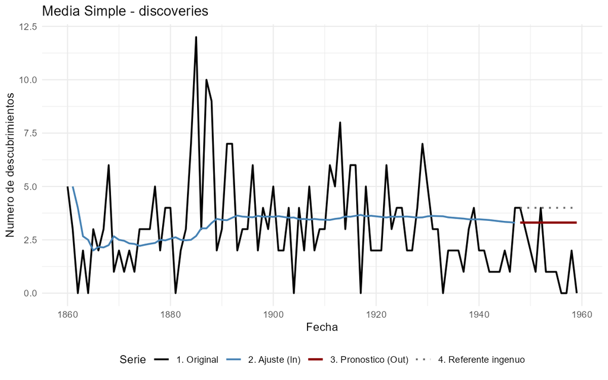

Media Simple: ajuste y pronóstico sobre el tramo de validación

### Conclusión

Se ajustó la media simple recursiva sobre 88 años de la serie `discoveries`, con pronóstico constante de 3.307 descubrimientos por año. En el tramo de validación ($h = 12$) su MAD fue 1.955, menor que el 2.417 del ingenuo, con MASE de 0.919. Los errores tienen media cero ($t = 0.194$) y no rechazan la independencia global con Ljung-Box ($Q = 27.643$, valor p $= 0.1506$), pero Durbin-Watson ($d = 1.504$) revela persistencia de primer orden y Jarque-Bera ($JB = 41.267$) rechaza la normalidad.

### Recomendación

Este pronóstico sirve a un historiador de la ciencia o a un editor que necesite una cifra de referencia sobre cuántos descubrimientos esperar por año. Como el pronóstico es constante, su calidad no se deteriora con el horizonte, y es razonable usarlo al menos hasta los 12 años validados. Su límite es que ignora las rachas de años más o menos productivos: el error absoluto medio de 1.955 equivale al 59.1% del nivel pronosticado, una incertidumbre relativa alta para decisiones año a año.

## 2. Media Móvil

```r
ejecutar_protocolo("discoveries", datasets::discoveries,
                   "The World Almanac and Book of Facts, 1975 Edition, pages 315-318",
                   "Numero de descubrimientos", "ajustar_mm", "Media Movil",
                   p_params = 1, prefijo = "02", param_rejilla = 2:12)
```

### Descripción de la serie

```r
ej <- resultados$ej02
c(N = ej$N, frecuencia = ej$frecuencia)
```

```
         N frecuencia
       100          1
```

```r
c(inicio = ej$fecha_ini, fin = ej$fecha_fin)
```

```
      inicio          fin
"1860-01-01" "1959-01-01"
```

Se usa de nuevo la serie `discoveries`. Fuente: The World Almanac and Book of Facts, 1975 Edition, pages 315-318. Unidad: numero de descubrimientos. Frecuencia anual, de 1860 a 1959, con $N = 100$ observaciones.

### Patrón de la serie

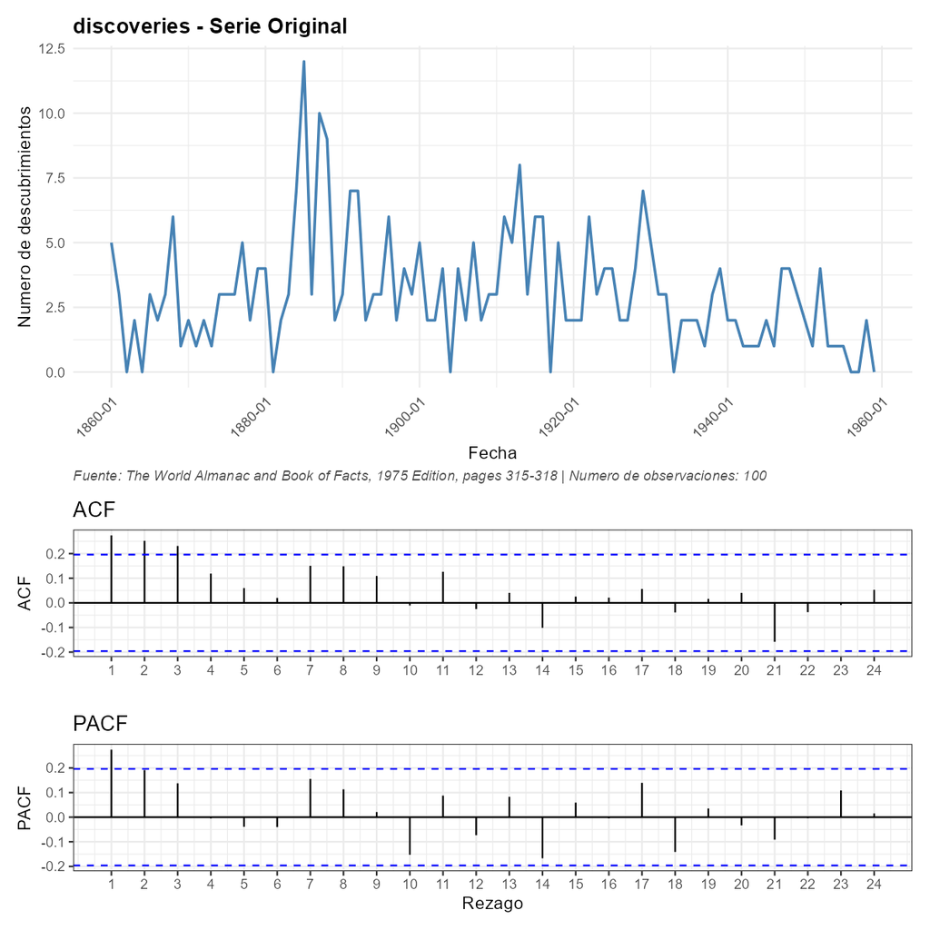

discoveries: serie original, ACF y PACF

**Contraste individual de las autocorrelaciones de la serie**

1. *Hipótesis:* para cada rezago $h = 1, \ldots, 24$, $H_0: \rho_h = 0$ frente a $H_1: \rho_h \neq 0$.
2. *Estadístico:* $r_h = c_h / c_0$, con $c_h = n^{-1}\sum_{t=1}^{n-h}(x_t - \bar x)(x_{t+h} - \bar x)$. Por el resultado de Bartlett, bajo ruido blanco $r_h \approx N(0, 1/n)$, con $n = 100$.
3. *Región de rechazo al 5%:* $|r_h| > z_{0.975}/\sqrt{n} = 1.96/\sqrt{100} = 0.1960$.
4. *Valores observados:* la tabla muestra $r_h$, $z = r_h\sqrt{n}$ y su valor p en los rezagos que sostienen la lectura.
5. *Decisión:* se rechaza $H_0$ en los rezagos 1, 2, 3 y no se rechaza en los demás de los 24 examinados.
6. *Lectura:* las autocorrelaciones significativas de los primeros rezagos indican que el nivel no es exactamente constante: se mueve lentamente, con rachas de años más y menos productivos. Ese es el supuesto de la media móvil, que promedia solo los años recientes para seguir un nivel que cambia localmente.

| Rezago $h$ | $r_h$ | $z$ | Valor p | Decisión |
| --- | --- | --- | --- | --- |
| 1 | 0.2741 | 2.741 | 0.0061 | Se rechaza |
| 2 | 0.2520 | 2.520 | 0.0117 | Se rechaza |
| 3 | 0.2310 | 2.310 | 0.0209 | Se rechaza |

**Prueba de Ljung-Box sobre la serie**

1. *Hipótesis:* $H_0: \rho_1 = \cdots = \rho_{24} = 0$ frente a $H_1$: al menos un $\rho_h \neq 0$ con $h \le 24$.
2. *Estadístico:* $Q_m = T(T+2)\sum_{h=1}^{m} r_h^2/(T-h)$, con $T = 100$ y $m = 24$. Bajo $H_0$, $Q_m \sim \chi^2_{m-p}$, con $p = 0$ parámetros estimados, es decir $\chi^2_{24}$.
3. *Región de rechazo al 5%:* $Q_m > \chi^2_{0.95;\,24} = 36.415$.
4. *Valor observado:* $Q_m = 36.254$, valor p $= 0.0518$.
5. *Decisión:* No se rechaza $H_0$ al 5%.
6. *Lectura:* la dependencia global es débil y no hay tendencia ni estacionalidad, así que un método de nivel es apropiado; la dependencia local de los primeros rezagos favorece un promedio de ventana corta sobre la media de todo el pasado.

### Partición y ajuste

El tramo de validación son las últimas $h = 12$ observaciones y el ajuste usa las primeras 88. La ventana se eligió con `optimizar()` minimizando el MSE de un paso en el tramo de estimación sobre la rejilla $k = 2, \ldots, 12$.

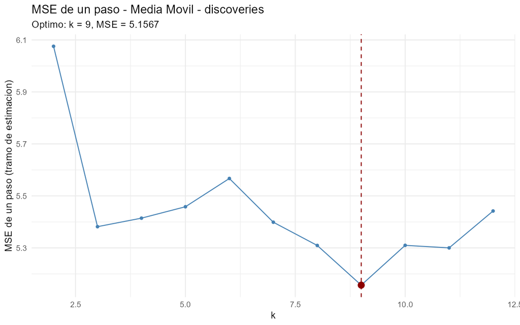

Media Móvil: MSE de un paso según la ventana k

El óptimo es $k = 9$, con MSE de 5.157. Está en el interior de la rejilla, de modo que la ventana no quedó forzada por los límites de búsqueda.

### Medidas de precisión

```r
round(rbind(metodo_estimacion    = ej$medidas_in,
            metodo_validacion    = ej$medidas_out,
            referente_validacion = ej$medidas_referente_out), 4)
```

```
                        MSE    MAD MAPE   MASE
metodo_estimacion    5.1567 1.7103  Inf 0.8043
metodo_validacion    2.0833 1.2500  Inf 0.5878
referente_validacion 7.7500 2.4167  Inf 1.1365
```

En validación, la media móvil obtiene un MAD de 1.250 frente a 2.417 del ingenuo, un error 48.3% menor, con MASE de 0.588. También mejora a la media simple del ejemplo 1, cuyo MAD fue 1.955. El MAPE es infinito por los años con cero descubrimientos.

### Validación de errores

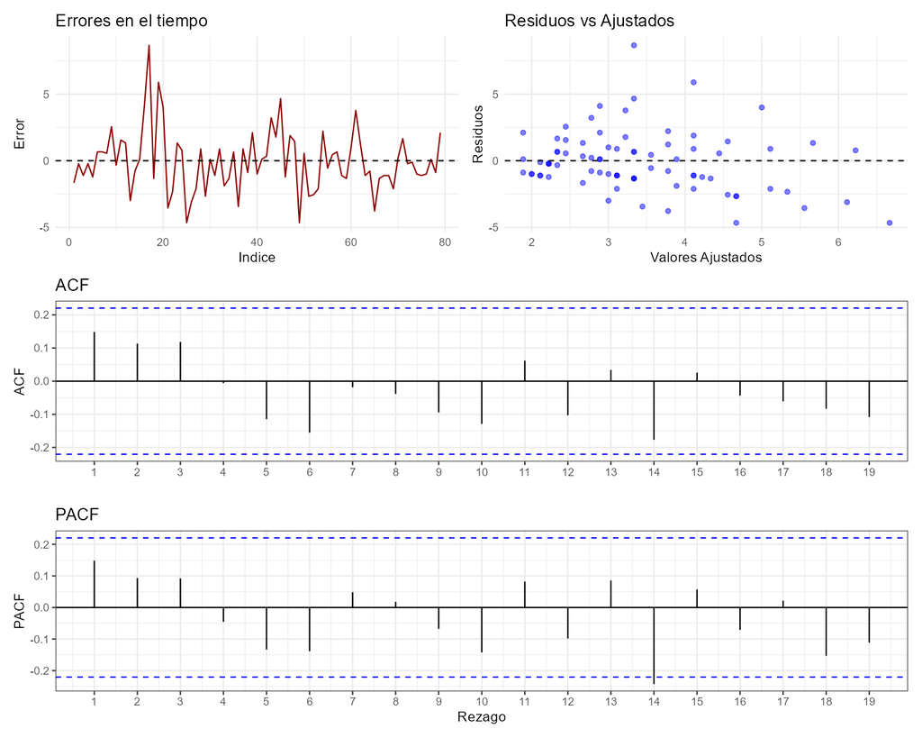

Media Móvil: diagnóstico de los errores

**Contraste individual de las autocorrelaciones de los errores**

1. *Hipótesis:* para cada rezago $h = 1, \ldots, 19$, $H_0: \rho_h = 0$ frente a $H_1: \rho_h \neq 0$.
2. *Estadístico:* $r_h = c_h / c_0$, con $c_h = n^{-1}\sum_{t=1}^{n-h}(x_t - \bar x)(x_{t+h} - \bar x)$. Por el resultado de Bartlett, bajo ruido blanco $r_h \approx N(0, 1/n)$, con $n = 79$.
3. *Región de rechazo al 5%:* $|r_h| > z_{0.975}/\sqrt{n} = 1.96/\sqrt{79} = 0.2205$.
4. *Valores observados:* la tabla muestra $r_h$, $z = r_h\sqrt{n}$ y su valor p en los rezagos que sostienen la lectura.
5. *Decisión:* no se rechaza $H_0$ en ninguno de los 19 rezagos examinados.
6. *Lectura:* a diferencia de la media simple, ninguna autocorrelación de los errores es significativa: al promediar los años recientes, la media móvil absorbe la persistencia de corto plazo.

| Rezago $h$ | $r_h$ | $z$ | Valor p | Decisión |
| --- | --- | --- | --- | --- |
| 1 | 0.1485 | 1.320 | 0.1868 | No se rechaza |

**Prueba t de media cero de los errores** ($N = 79$ errores)

1. *Hipótesis:* $H_0: \mu_e = 0$ frente a $H_1: \mu_e \neq 0$.
2. *Estadístico:* $t = \sqrt{N}\,\bar e / s_e$. Bajo $H_0$, $t \sim t_{N-1} = t_{78}$.
3. *Región de rechazo al 5%:* $|t| > t_{0.975;\,78} = 1.991$.
4. *Valor observado:* $t = -0.230$, valor p $= 0.8188$.
5. *Decisión:* No se rechaza $H_0$ al 5%.
6. *Lectura:* los errores no están sesgados.

**Prueba de Ljung-Box sobre los errores**

1. *Hipótesis:* $H_0: \rho_1 = \cdots = \rho_{19} = 0$ frente a $H_1$: al menos un $\rho_h \neq 0$ con $h \le 19$.
2. *Estadístico:* $Q_m = T(T+2)\sum_{h=1}^{m} r_h^2/(T-h)$, con $T = 79$ y $m = 19$. Bajo $H_0$, $Q_m \sim \chi^2_{m-p}$, con $p = 1$ parámetros estimados, es decir $\chi^2_{18}$.
3. *Región de rechazo al 5%:* $Q_m > \chi^2_{0.95;\,18} = 28.869$.
4. *Valor observado:* $Q_m = 17.005$, valor p $= 0.5228$.
5. *Decisión:* No se rechaza $H_0$ al 5%.
6. *Lectura:* los errores se comportan como ruido blanco: el método captura toda la estructura de dependencia de la serie.

**Prueba de Jarque-Bera** ($N = 79$ errores)

1. *Hipótesis:* $H_0$: los errores son normales ($A = 0$ y $K = 3$) frente a $H_1$: no son normales.
2. *Estadístico:* $JB = \frac{N}{6}\left[A^2 + \frac{(K-3)^2}{4}\right]$, con asimetría $A = 0.862$ y curtosis $K = 4.969$. Bajo $H_0$, $JB \sim \chi^2_2$ de forma asintótica.
3. *Región de rechazo al 5%:* $JB > \chi^2_{0.95;\,2} = 5.991$.
4. *Valor observado:* $JB = 22.548$, valor p $< 0.0001$.
5. *Decisión:* Se rechaza $H_0$ al 5%.
6. *Lectura:* los errores no son normales, por la asimetría positiva propia de un conteo con años excepcionales.

**Prueba de Durbin-Watson** ($N = 79$ errores)

1. *Hipótesis:* $H_0: \rho_1 = 0$ frente a $H_1: \rho_1 \neq 0$.
2. *Estadístico:* $d = \sum_{t=2}^{N}(e_t - e_{t-1})^2 / \sum_{t=1}^{N} e_t^2 \approx 2(1 - r_1)$. Las cotas $d_L$ y $d_U$ solo aplican a residuos de una regresión; para los errores de un método se usa que, bajo $H_0$, $r_1 \approx N(0, 1/N)$, de modo que $z = (2 - d)\sqrt{N}/2 \approx N(0, 1)$.
3. *Región de rechazo al 5%:* $|z| > 1.96$, equivalente a $d < 1.559$ o $d > 2.441$.
4. *Valor observado:* $d = 1.684$, $z = 1.405$, valor p $= 0.1601$.
5. *Decisión:* No se rechaza $H_0$ al 5%.
6. *Lectura:* no queda autocorrelación de primer orden en los errores.

### Pronóstico

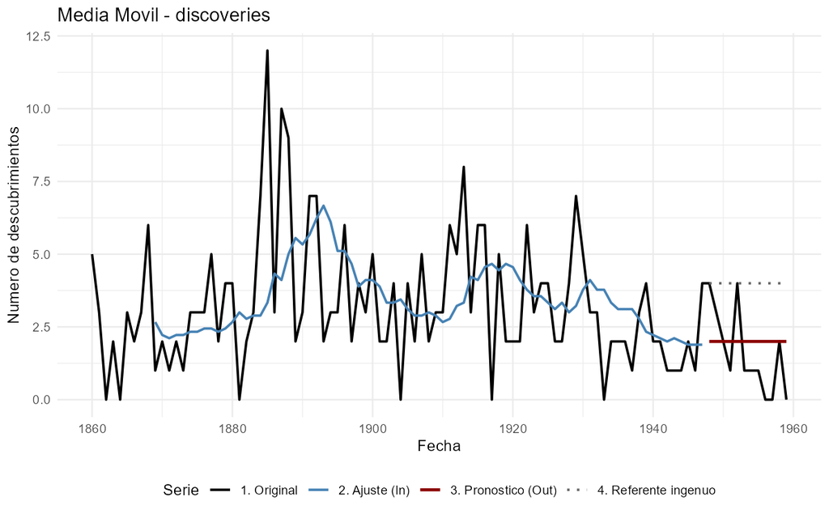

Media Móvil: ajuste y pronóstico sobre el tramo de validación

### Conclusión

Se ajustó una media móvil de orden $k = 9$, elegido por `optimizar()`, con pronóstico constante de 2.000 descubrimientos por año. En validación ($h = 12$) su MAD fue 1.250, frente a 2.417 del ingenuo, con MASE de 0.588. Los errores cumplen media cero ($t = -0.230$), independencia según Ljung-Box ($Q = 17.005$, valor p $= 0.5228$) y Durbin-Watson ($d = 1.684$), pero no normalidad ($JB = 22.548$).

### Recomendación

Este pronóstico sirve para estimar la tasa de descubrimientos del período reciente, por ejemplo para un historiador que compare décadas. Es razonable hasta los 12 años validados, porque el nivel cambia despacio. Su límite es el rezago de reacción: al promediar 9 años, tarda varios años en reflejar un cambio de nivel, y en validación su mayor error absoluto fue de 2.0 descubrimientos en un solo año. Además, como los errores no son normales, los intervalos de pronóstico basados en la normal no serían confiables.

## 3. Suavizamiento Exponencial Simple

```r
ejecutar_protocolo("Nile", datasets::Nile,
                   "Durbin, J. and Koopman, S. J. (2001) Time Series Analysis by State Space Methods. Oxford University Press",
                   "Flujo anual (10^8 m^3)", "ajustar_ses", "Suavizamiento Exponencial Simple",
                   p_params = 1, prefijo = "03", param_rejilla = seq(0.02, 0.98, by = 0.02))
```

### Descripción de la serie

```r
ej <- resultados$ej03
c(N = ej$N, frecuencia = ej$frecuencia)
```

```
         N frecuencia
       100          1
```

```r
c(inicio = ej$fecha_ini, fin = ej$fecha_fin)
```

```
      inicio          fin
"1871-01-01" "1970-01-01"
```

La serie `Nile` mide el caudal anual del río Nilo en Asuán. Fuente: Durbin, J. and Koopman, S. J. (2001) Time Series Analysis by State Space Methods. Oxford University Press. Unidad: flujo anual en $10^8\,m^3$. Frecuencia anual, de 1871 a 1970, con $N = 100$ observaciones.

### Patrón de la serie

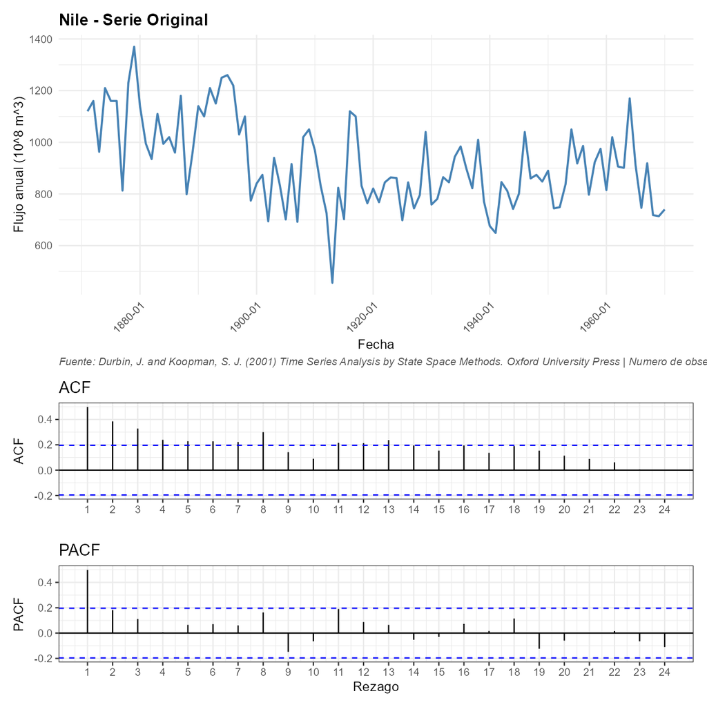

Nile: serie original, ACF y PACF

La serie no tiene una tendencia sostenida, pero su nivel cambia: alrededor de 1898 el caudal cae a un nivel más bajo y se mantiene allí. Un nivel que se desplaza en el tiempo, sin pendiente, es el supuesto del suavizamiento exponencial simple, que actualiza el nivel con cada observación nueva.

**Contraste individual de las autocorrelaciones de la serie**

1. *Hipótesis:* para cada rezago $h = 1, \ldots, 24$, $H_0: \rho_h = 0$ frente a $H_1: \rho_h \neq 0$.
2. *Estadístico:* $r_h = c_h / c_0$, con $c_h = n^{-1}\sum_{t=1}^{n-h}(x_t - \bar x)(x_{t+h} - \bar x)$. Por el resultado de Bartlett, bajo ruido blanco $r_h \approx N(0, 1/n)$, con $n = 100$.
3. *Región de rechazo al 5%:* $|r_h| > z_{0.975}/\sqrt{n} = 1.96/\sqrt{100} = 0.1960$.
4. *Valores observados:* la tabla muestra $r_h$, $z = r_h\sqrt{n}$ y su valor p en los rezagos que sostienen la lectura.
5. *Decisión:* se rechaza $H_0$ en los rezagos 1, 2, 3, 4, 5, 6, 7, 8, 11, 12, 13 y no se rechaza en los demás de los 24 examinados.
6. *Lectura:* las autocorrelaciones son positivas y significativas en muchos rezagos, algo que se espera cuando el nivel cambia: los años anteriores al quiebre se parecen entre sí, y lo mismo ocurre después. Un nivel fijo no describiría bien la serie.

| Rezago $h$ | $r_h$ | $z$ | Valor p | Decisión |
| --- | --- | --- | --- | --- |
| 1 | 0.4984 | 4.984 | < 0.0001 | Se rechaza |
| 2 | 0.3846 | 3.846 | 0.0001 | Se rechaza |
| 3 | 0.3279 | 3.279 | 0.0010 | Se rechaza |
| 4 | 0.2392 | 2.392 | 0.0168 | Se rechaza |
| 5 | 0.2284 | 2.284 | 0.0224 | Se rechaza |
| 6 | 0.2273 | 2.273 | 0.0230 | Se rechaza |

**Prueba de Ljung-Box sobre la serie**

1. *Hipótesis:* $H_0: \rho_1 = \cdots = \rho_{24} = 0$ frente a $H_1$: al menos un $\rho_h \neq 0$ con $h \le 24$.
2. *Estadístico:* $Q_m = T(T+2)\sum_{h=1}^{m} r_h^2/(T-h)$, con $T = 100$ y $m = 24$. Bajo $H_0$, $Q_m \sim \chi^2_{m-p}$, con $p = 0$ parámetros estimados, es decir $\chi^2_{24}$.
3. *Región de rechazo al 5%:* $Q_m > \chi^2_{0.95;\,24} = 36.415$.
4. *Valor observado:* $Q_m = 130.180$, valor p $< 0.0001$.
5. *Decisión:* Se rechaza $H_0$ al 5%.
6. *Lectura:* la serie tiene una dependencia temporal fuerte, así que un método que se apoye en el pasado reciente, como el SES, tiene información útil que aprovechar.

### Partición y ajuste

El tramo de validación son las últimas $h = 12$ observaciones y el ajuste usa las primeras 88. La constante se eligió con `optimizar()` sobre la rejilla $\alpha = 0.02, 0.04, \ldots, 0.98$.

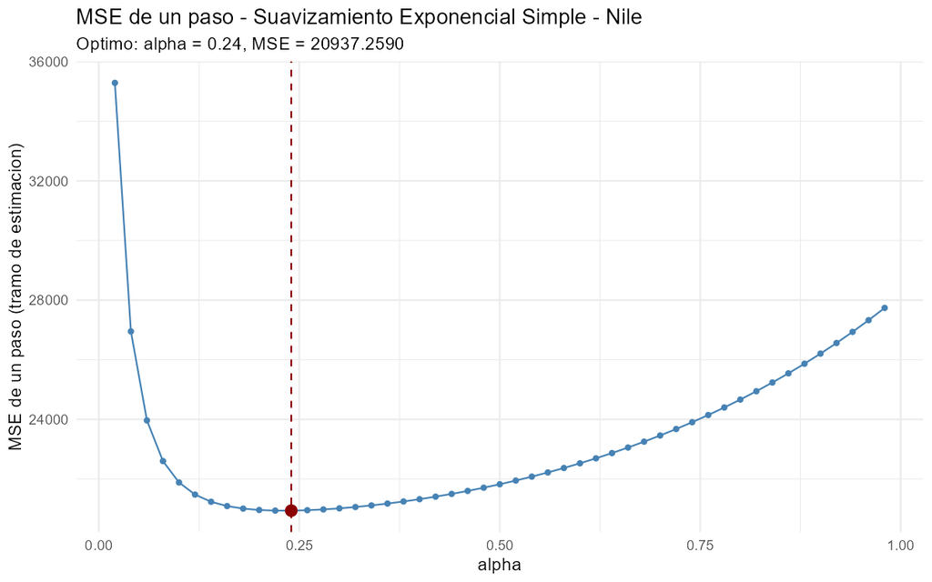

SES: MSE de un paso según alpha

El óptimo es $\alpha = 0.24$, con MSE de 20937.3. Está en el interior de la rejilla: el nivel se actualiza con un peso moderado a la última observación, lo que confirma que la serie tiene un nivel que cambia, pero no tan rápido como para que convenga el ingenuo ($\alpha$ cercano a 1).

### Medidas de precisión

```r
round(rbind(metodo_estimacion    = ej$medidas_in,
            metodo_validacion    = ej$medidas_out,
            referente_validacion = ej$medidas_referente_out), 4)
```

```
                          MSE      MAD    MAPE   MASE
metodo_estimacion    20937.26 113.6056 13.0893 0.8551
metodo_validacion    17864.46 107.1168 12.6004 0.8062
referente_validacion 19685.00 111.0000 13.4537 0.8355
```

En validación, el SES obtiene un MAD de 107.12 frente a 111.00 del ingenuo, un error 3.5% menor. El MAPE es 12.60% y el MASE 0.806.

### Validación de errores

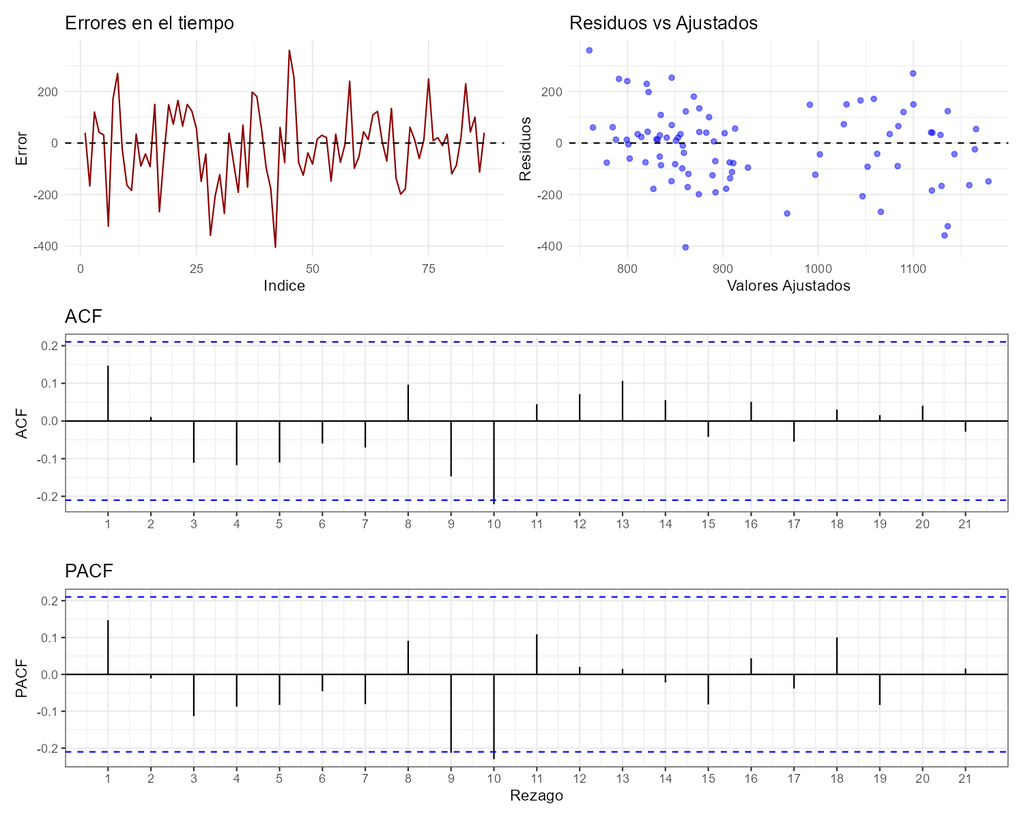

SES: diagnóstico de los errores

**Contraste individual de las autocorrelaciones de los errores**

1. *Hipótesis:* para cada rezago $h = 1, \ldots, 21$, $H_0: \rho_h = 0$ frente a $H_1: \rho_h \neq 0$.
2. *Estadístico:* $r_h = c_h / c_0$, con $c_h = n^{-1}\sum_{t=1}^{n-h}(x_t - \bar x)(x_{t+h} - \bar x)$. Por el resultado de Bartlett, bajo ruido blanco $r_h \approx N(0, 1/n)$, con $n = 87$.
3. *Región de rechazo al 5%:* $|r_h| > z_{0.975}/\sqrt{n} = 1.96/\sqrt{87} = 0.2101$.
4. *Valores observados:* la tabla muestra $r_h$, $z = r_h\sqrt{n}$ y su valor p en los rezagos que sostienen la lectura.
5. *Decisión:* se rechaza $H_0$ en los rezagos 10 y no se rechaza en los demás de los 21 examinados.
6. *Lectura:* solo un rezago aislado sale de la banda, lo esperable por azar al examinar tantos rezagos al 5%. No hay un patrón de autocorrelación en los errores.

| Rezago $h$ | $r_h$ | $z$ | Valor p | Decisión |
| --- | --- | --- | --- | --- |
| 1 | 0.1470 | 1.371 | 0.1705 | No se rechaza |
| 10 | -0.2206 | -2.058 | 0.0396 | Se rechaza |

**Prueba t de media cero de los errores** ($N = 87$ errores)

1. *Hipótesis:* $H_0: \mu_e = 0$ frente a $H_1: \mu_e \neq 0$.
2. *Estadístico:* $t = \sqrt{N}\,\bar e / s_e$. Bajo $H_0$, $t \sim t_{N-1} = t_{86}$.
3. *Región de rechazo al 5%:* $|t| > t_{0.975;\,86} = 1.988$.
4. *Valor observado:* $t = -0.701$, valor p $= 0.4853$.
5. *Decisión:* No se rechaza $H_0$ al 5%.
6. *Lectura:* los errores no están sesgados: el SES no sobreestima ni subestima el caudal de forma sistemática.

**Prueba de Ljung-Box sobre los errores**

1. *Hipótesis:* $H_0: \rho_1 = \cdots = \rho_{21} = 0$ frente a $H_1$: al menos un $\rho_h \neq 0$ con $h \le 21$.
2. *Estadístico:* $Q_m = T(T+2)\sum_{h=1}^{m} r_h^2/(T-h)$, con $T = 87$ y $m = 21$. Bajo $H_0$, $Q_m \sim \chi^2_{m-p}$, con $p = 1$ parámetros estimados, es decir $\chi^2_{20}$.
3. *Región de rechazo al 5%:* $Q_m > \chi^2_{0.95;\,20} = 31.410$.
4. *Valor observado:* $Q_m = 17.757$, valor p $= 0.6034$.
5. *Decisión:* No se rechaza $H_0$ al 5%.
6. *Lectura:* los errores se comportan como ruido blanco: el SES captura la dependencia que tenía la serie.

**Prueba de Jarque-Bera** ($N = 87$ errores)

1. *Hipótesis:* $H_0$: los errores son normales ($A = 0$ y $K = 3$) frente a $H_1$: no son normales.
2. *Estadístico:* $JB = \frac{N}{6}\left[A^2 + \frac{(K-3)^2}{4}\right]$, con asimetría $A = -0.133$ y curtosis $K = 3.144$. Bajo $H_0$, $JB \sim \chi^2_2$ de forma asintótica.
3. *Región de rechazo al 5%:* $JB > \chi^2_{0.95;\,2} = 5.991$.
4. *Valor observado:* $JB = 0.330$, valor p $= 0.8477$.
5. *Decisión:* No se rechaza $H_0$ al 5%.
6. *Lectura:* los errores son compatibles con una distribución normal.

**Prueba de Durbin-Watson** ($N = 87$ errores)

1. *Hipótesis:* $H_0: \rho_1 = 0$ frente a $H_1: \rho_1 \neq 0$.
2. *Estadístico:* $d = \sum_{t=2}^{N}(e_t - e_{t-1})^2 / \sum_{t=1}^{N} e_t^2 \approx 2(1 - r_1)$. Las cotas $d_L$ y $d_U$ solo aplican a residuos de una regresión; para los errores de un método se usa que, bajo $H_0$, $r_1 \approx N(0, 1/N)$, de modo que $z = (2 - d)\sqrt{N}/2 \approx N(0, 1)$.
3. *Región de rechazo al 5%:* $|z| > 1.96$, equivalente a $d < 1.580$ o $d > 2.420$.
4. *Valor observado:* $d = 1.694$, $z = 1.429$, valor p $= 0.1529$.
5. *Decisión:* No se rechaza $H_0$ al 5%.
6. *Lectura:* no queda autocorrelación de primer orden en los errores.

### Pronóstico

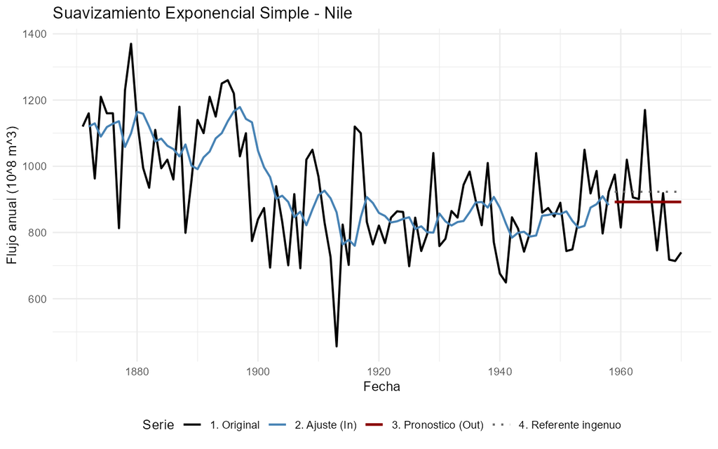

SES: ajuste y pronóstico sobre el tramo de validación

### Conclusión

Se ajustó el suavizamiento exponencial simple con $\alpha = 0.24$, elegido por `optimizar()`, con pronóstico constante de 892.3 $\times 10^8\,m^3$. En validación ($h = 12$) su MAD fue 107.12, frente a 111.00 del ingenuo, con MAPE de 12.60% y MASE de 0.806. Los errores cumplen todos los supuestos: media cero ($t = -0.701$), independencia según Ljung-Box ($Q = 17.757$, valor p $= 0.6034$) y Durbin-Watson ($d = 1.694$), y normalidad ($JB = 0.330$, valor p $= 0.8477$).

### Recomendación

Este pronóstico sirve a quienes planean el uso del agua del Nilo, como autoridades de riego o de generación hidroeléctrica, que necesitan una estimación del caudal esperado. Es razonable hasta los 12 años validados, porque el pronóstico es un nivel y el caudal no tiene tendencia. Su límite es que no anticipa cambios de nivel como el de 1898 ni los años extremos: la ventaja sobre el ingenuo es de apenas 3.5%, y en validación el mayor error absoluto fue de 277.7 $\times 10^8\,m^3$ en un solo año.

## 4. Doble Media Móvil

```r
ejecutar_protocolo("WWWusage", datasets::WWWusage,
                   "Durbin, J. and Koopman, S. J. (2001) Time Series Analysis by State Space Methods. Oxford University Press",
                   "Usuarios conectados por minuto", "ajustar_dmm", "Doble Media Movil",
                   p_params = 1, prefijo = "04", param_rejilla = 2:12)
```

### Descripción de la serie

```r
ej <- resultados$ej04
c(N = ej$N, frecuencia = ej$frecuencia)
```

```
         N frecuencia
       100          1
```

```r
c(inicio = ej$fecha_ini, fin = ej$fecha_fin)
```

```
      inicio          fin
"0001-01-01" "0100-01-01"
```

La serie `WWWusage` registra el número de usuarios conectados a internet a través de un servidor, medido cada minuto. Fuente: Durbin, J. and Koopman, S. J. (2001) Time Series Analysis by State Space Methods. Oxford University Press. Unidad: usuarios conectados por minuto. R la almacena como una serie de frecuencia 1 que empieza en el período 1, así que `leer_serie()` le asigna fechas desde el año 1; esas fechas son solo un índice de minutos, del 1 al 100, con $N = 100$ observaciones.

### Patrón de la serie

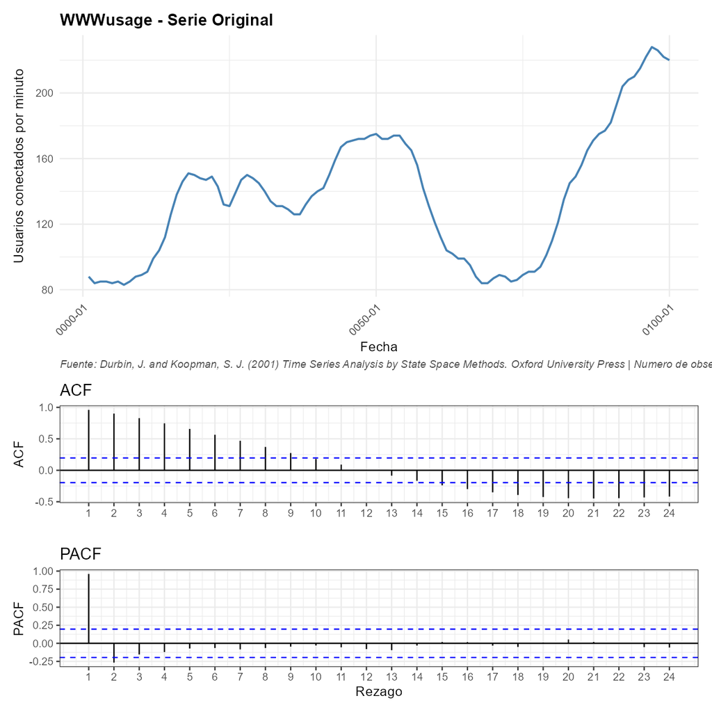

WWWusage: serie original, ACF y PACF

La serie sube y baja en tramos largos: tiene tendencias locales que cambian de dirección, sin una tendencia global única. Ese es el supuesto de la doble media móvil, que estima un nivel y una pendiente locales y los actualiza a medida que avanza.

**Contraste individual de las autocorrelaciones de la serie**

1. *Hipótesis:* para cada rezago $h = 1, \ldots, 24$, $H_0: \rho_h = 0$ frente a $H_1: \rho_h \neq 0$.
2. *Estadístico:* $r_h = c_h / c_0$, con $c_h = n^{-1}\sum_{t=1}^{n-h}(x_t - \bar x)(x_{t+h} - \bar x)$. Por el resultado de Bartlett, bajo ruido blanco $r_h \approx N(0, 1/n)$, con $n = 100$.
3. *Región de rechazo al 5%:* $|r_h| > z_{0.975}/\sqrt{n} = 1.96/\sqrt{100} = 0.1960$.
4. *Valores observados:* la tabla muestra $r_h$, $z = r_h\sqrt{n}$ y su valor p en los rezagos que sostienen la lectura.
5. *Decisión:* se rechaza $H_0$ en los rezagos 1, 2, 3, 4, 5, 6, 7, 8, 9, 15, 16, 17, 18, 19, 20, 21, 22, 23, 24 y no se rechaza en los demás de los 24 examinados.
6. *Lectura:* la ACF es positiva y decae despacio en los primeros rezagos y luego se vuelve negativa en los rezagos altos. Ese patrón aparece cuando la serie pasa tramos largos por encima y por debajo de su media, es decir, cuando tiene tendencias locales que se revierten.

| Rezago $h$ | $r_h$ | $z$ | Valor p | Decisión |
| --- | --- | --- | --- | --- |
| 1 | 0.9602 | 9.602 | < 0.0001 | Se rechaza |
| 2 | 0.9011 | 9.011 | < 0.0001 | Se rechaza |
| 5 | 0.6572 | 6.572 | < 0.0001 | Se rechaza |
| 9 | 0.2742 | 2.742 | 0.0061 | Se rechaza |
| 15 | -0.2389 | -2.389 | 0.0169 | Se rechaza |
| 20 | -0.4429 | -4.429 | < 0.0001 | Se rechaza |

**Prueba de Ljung-Box sobre la serie**

1. *Hipótesis:* $H_0: \rho_1 = \cdots = \rho_{24} = 0$ frente a $H_1$: al menos un $\rho_h \neq 0$ con $h \le 24$.
2. *Estadístico:* $Q_m = T(T+2)\sum_{h=1}^{m} r_h^2/(T-h)$, con $T = 100$ y $m = 24$. Bajo $H_0$, $Q_m \sim \chi^2_{m-p}$, con $p = 0$ parámetros estimados, es decir $\chi^2_{24}$.
3. *Región de rechazo al 5%:* $Q_m > \chi^2_{0.95;\,24} = 36.415$.
4. *Valor observado:* $Q_m = 647.798$, valor p $< 0.0001$.
5. *Decisión:* Se rechaza $H_0$ al 5%.
6. *Lectura:* la dependencia temporal es muy fuerte: cada minuto se parece mucho a los anteriores, así que la dirección reciente de la serie es informativa para pronosticar.

### Partición y ajuste

El tramo de validación son las últimas $h = 12$ observaciones y el ajuste usa las primeras 88. La ventana se eligió con `optimizar()` sobre la rejilla $k = 2, \ldots, 12$.

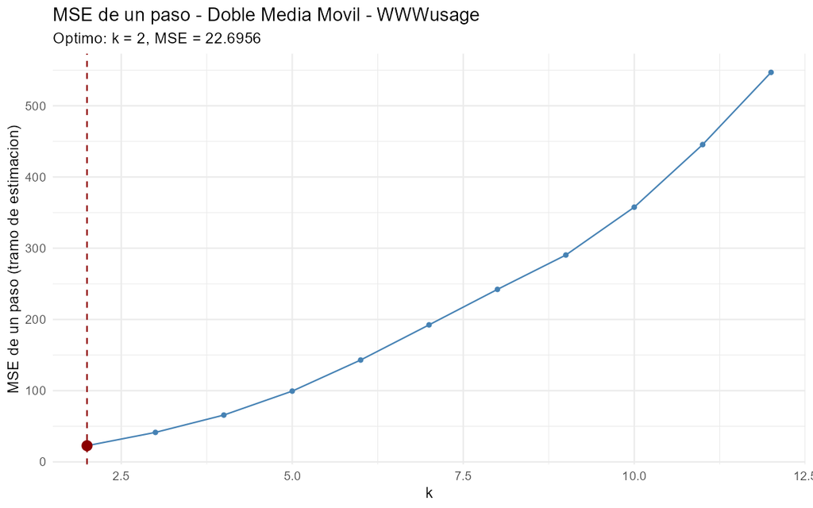

Doble Media Móvil: MSE de un paso según la ventana k

El óptimo es $k = 2$, con MSE de 22.696, y cae en el borde inferior de la rejilla. La curva sube de forma monótona hasta un MSE de 547.0 con $k = 12$, es decir, el MSE baja a medida que la ventana se acorta: la pendiente de la serie cambia tan rápido que cualquier ventana más larga reacciona tarde. Con $k = 2$, la doble media móvil es lo más reactiva que puede ser y se acerca a proyectar el cambio más reciente de la serie.

### Medidas de precisión

```r
round(rbind(metodo_estimacion    = ej$medidas_in,
            metodo_validacion    = ej$medidas_out,
            referente_validacion = ej$medidas_referente_out), 4)
```

```
                           MSE     MAD    MAPE   MASE
metodo_estimacion      22.6956  3.8294  3.0668 0.8609
metodo_validacion      50.9167  6.0833  2.8764 1.3676
referente_validacion 1415.4167 33.9167 15.6886 7.6247
```

En validación, la doble media móvil obtiene un MAD de 6.08 usuarios frente a 33.92 del ingenuo, es decir, un error 82.1% menor, con MAPE de 2.88%. El MASE es 1.368, mayor que 1, pero eso no indica que pierda contra el referente: el MASE se escala con el error del ingenuo de un paso en el tramo de estimación (4.45), mientras que en validación se pronostica hasta 12 minutos adelante. En ese tramo la serie tiene una pendiente marcada que el ingenuo, al congelar el último valor, no sigue.

### Validación de errores

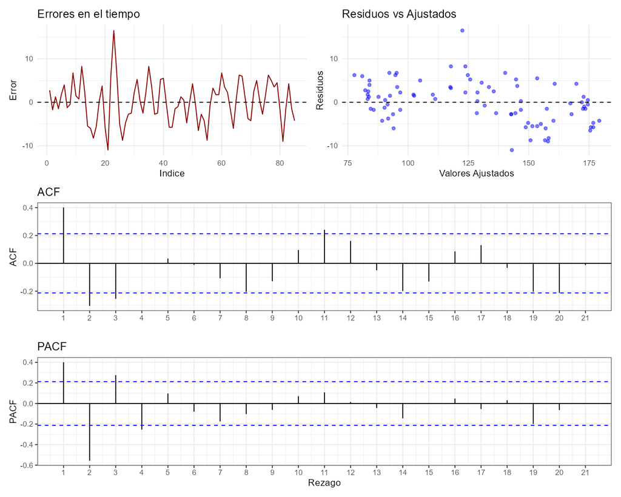

Doble Media Móvil: diagnóstico de los errores

**Contraste individual de las autocorrelaciones de los errores**

1. *Hipótesis:* para cada rezago $h = 1, \ldots, 21$, $H_0: \rho_h = 0$ frente a $H_1: \rho_h \neq 0$.
2. *Estadístico:* $r_h = c_h / c_0$, con $c_h = n^{-1}\sum_{t=1}^{n-h}(x_t - \bar x)(x_{t+h} - \bar x)$. Por el resultado de Bartlett, bajo ruido blanco $r_h \approx N(0, 1/n)$, con $n = 85$.
3. *Región de rechazo al 5%:* $|r_h| > z_{0.975}/\sqrt{n} = 1.96/\sqrt{85} = 0.2126$.
4. *Valores observados:* la tabla muestra $r_h$, $z = r_h\sqrt{n}$ y su valor p en los rezagos que sostienen la lectura.
5. *Decisión:* se rechaza $H_0$ en los rezagos 1, 2, 3, 11 y no se rechaza en los demás de los 21 examinados.
6. *Lectura:* los primeros rezagos siguen fuera de la banda: los errores de minutos consecutivos se parecen, porque la pendiente estimada con dos períodos es ruidosa y el método sobrerreacciona en los cambios de dirección.

| Rezago $h$ | $r_h$ | $z$ | Valor p | Decisión |
| --- | --- | --- | --- | --- |
| 1 | 0.4013 | 3.700 | 0.0002 | Se rechaza |
| 2 | -0.3058 | -2.819 | 0.0048 | Se rechaza |
| 3 | -0.2548 | -2.349 | 0.0188 | Se rechaza |
| 11 | 0.2411 | 2.222 | 0.0263 | Se rechaza |

**Prueba t de media cero de los errores** ($N = 85$ errores)

1. *Hipótesis:* $H_0: \mu_e = 0$ frente a $H_1: \mu_e \neq 0$.
2. *Estadístico:* $t = \sqrt{N}\,\bar e / s_e$. Bajo $H_0$, $t \sim t_{N-1} = t_{84}$.
3. *Región de rechazo al 5%:* $|t| > t_{0.975;\,84} = 1.989$.
4. *Valor observado:* $t = 0.238$, valor p $= 0.8127$.
5. *Decisión:* No se rechaza $H_0$ al 5%.
6. *Lectura:* los errores no están sesgados.

**Prueba de Ljung-Box sobre los errores**

1. *Hipótesis:* $H_0: \rho_1 = \cdots = \rho_{21} = 0$ frente a $H_1$: al menos un $\rho_h \neq 0$ con $h \le 21$.
2. *Estadístico:* $Q_m = T(T+2)\sum_{h=1}^{m} r_h^2/(T-h)$, con $T = 85$ y $m = 21$. Bajo $H_0$, $Q_m \sim \chi^2_{m-p}$, con $p = 1$ parámetros estimados, es decir $\chi^2_{20}$.
3. *Región de rechazo al 5%:* $Q_m > \chi^2_{0.95;\,20} = 31.410$.
4. *Valor observado:* $Q_m = 63.261$, valor p $< 0.0001$.
5. *Decisión:* Se rechaza $H_0$ al 5%.
6. *Lectura:* queda autocorrelación que el método no captura: la dinámica del tráfico tiene más estructura que un nivel y una pendiente locales.

**Prueba de Jarque-Bera** ($N = 85$ errores)

1. *Hipótesis:* $H_0$: los errores son normales ($A = 0$ y $K = 3$) frente a $H_1$: no son normales.
2. *Estadístico:* $JB = \frac{N}{6}\left[A^2 + \frac{(K-3)^2}{4}\right]$, con asimetría $A = 0.192$ y curtosis $K = 3.447$. Bajo $H_0$, $JB \sim \chi^2_2$ de forma asintótica.
3. *Región de rechazo al 5%:* $JB > \chi^2_{0.95;\,2} = 5.991$.
4. *Valor observado:* $JB = 1.229$, valor p $= 0.5408$.
5. *Decisión:* No se rechaza $H_0$ al 5%.
6. *Lectura:* los errores son compatibles con una distribución normal.

**Prueba de Durbin-Watson** ($N = 85$ errores)

1. *Hipótesis:* $H_0: \rho_1 = 0$ frente a $H_1: \rho_1 \neq 0$.
2. *Estadístico:* $d = \sum_{t=2}^{N}(e_t - e_{t-1})^2 / \sum_{t=1}^{N} e_t^2 \approx 2(1 - r_1)$. Las cotas $d_L$ y $d_U$ solo aplican a residuos de una regresión; para los errores de un método se usa que, bajo $H_0$, $r_1 \approx N(0, 1/N)$, de modo que $z = (2 - d)\sqrt{N}/2 \approx N(0, 1)$.
3. *Región de rechazo al 5%:* $|z| > 1.96$, equivalente a $d < 1.575$ o $d > 2.425$.
4. *Valor observado:* $d = 1.183$, $z = 3.766$, valor p $= 0.0002$.
5. *Decisión:* Se rechaza $H_0$ al 5%.
6. *Lectura:* hay autocorrelación positiva de primer orden, coherente con el primer rezago fuera de la banda.

### Pronóstico

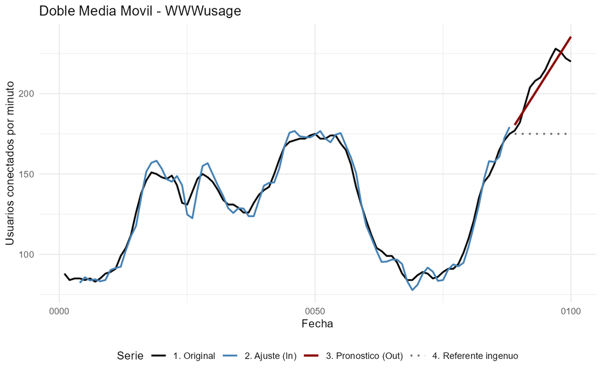

Doble Media Móvil: ajuste y pronóstico sobre el tramo de validación

### Conclusión

Se ajustó una doble media móvil de orden $k = 2$, elegido por `optimizar()` en el borde inferior de la rejilla. En validación ($h = 12$) su MAD fue 6.08 usuarios, muy por debajo de los 33.92 del ingenuo, con MAPE de 2.88%. Los errores tienen media cero ($t = 0.238$) y son normales ($JB = 1.229$), pero conservan autocorrelación según Ljung-Box ($Q = 63.261$, valor p $< 0.0001$) y Durbin-Watson ($d = 1.183$).

### Recomendación

Este pronóstico sirve a un administrador de red que deba asignar capacidad de conexión en los minutos siguientes. Es razonable solo a corto plazo, porque el método prolonga en línea recta la pendiente estimada con los últimos minutos: en validación, el error absoluto fue de 3.5 usuarios en el primer minuto pronosticado y llegó a 15.5 en el peor minuto del horizonte. Su límite es que no anticipa los cambios de dirección del tráfico, y la autocorrelación que queda en los errores indica que un modelo con más memoria podría mejorarlo.

## 5. Tendencia Lineal

```r
ejecutar_protocolo("austres", datasets::austres,
                   "P. J. Brockwell and R. A. Davis (1996) Introduction to Time Series and Forecasting. Springer",
                   "Miles de residentes", "ajustar_tendencia", "Tendencia Lineal",
                   p_params = 2, prefijo = "05", es_tendencia = TRUE, tipo_tend = "lineal",
                   estacional = FALSE, dL = 1.598, dU = 1.652)
```

### Descripción de la serie

```r
ej <- resultados$ej05
c(N = ej$N, frecuencia = ej$frecuencia)
```

```
         N frecuencia
        89          4
```

```r
c(inicio = ej$fecha_ini, fin = ej$fecha_fin)
```

```
      inicio          fin
"1971-04-01" "1993-04-01"
```

La serie `austres` registra el número de residentes de Australia, medido trimestralmente. Fuente: P. J. Brockwell and R. A. Davis (1996) Introduction to Time Series and Forecasting. Springer. Unidad: miles de residentes. Frecuencia trimestral, de 1971-T2 a 1993-T2, con $N = 89$ observaciones. Aunque es trimestral, la población no tiene un patrón estacional, así que el referente es el ingenuo simple y no el estacional.

### Patrón de la serie

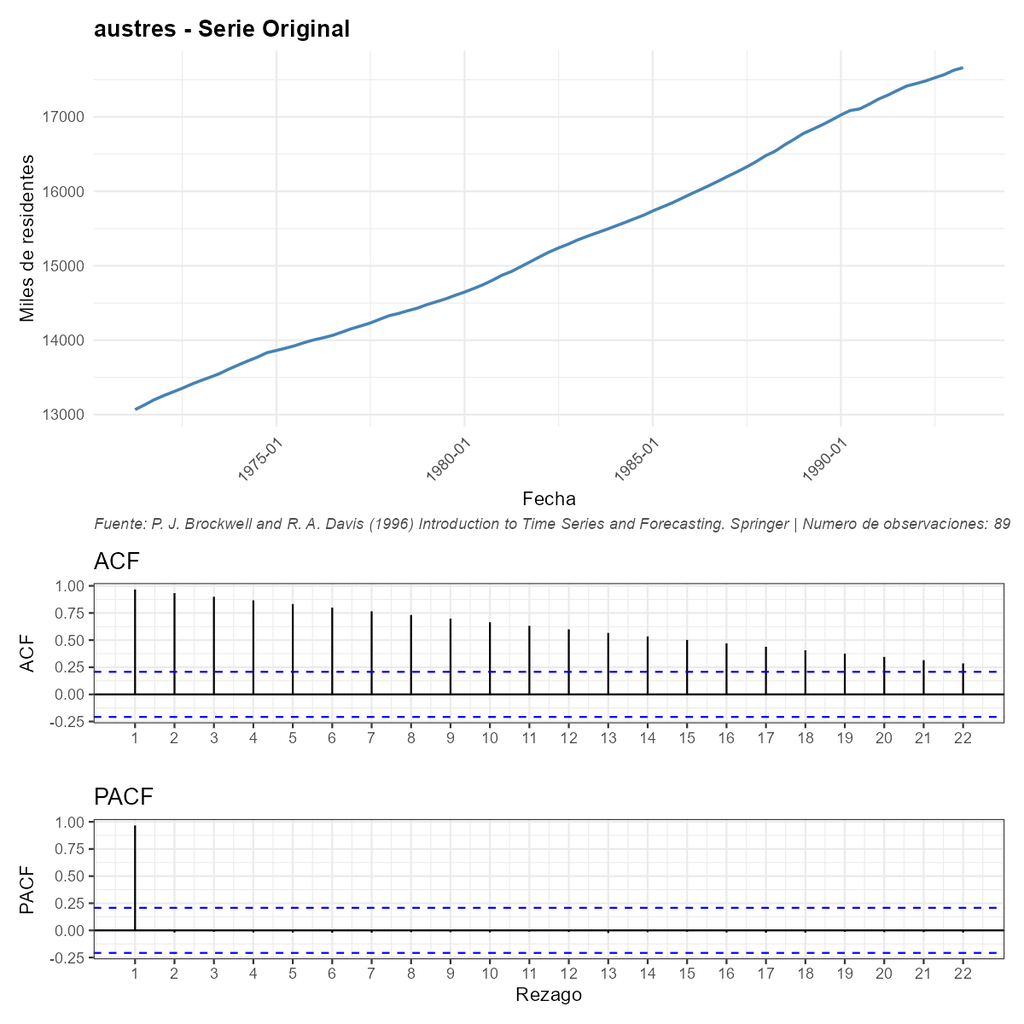

austres: serie original, ACF y PACF

La población crece de forma casi recta durante todo el período, sin curvatura visible ni estacionalidad. Ese es el supuesto de la tendencia lineal: un crecimiento de magnitud constante por período.

**Contraste individual de las autocorrelaciones de la serie**

1. *Hipótesis:* para cada rezago $h = 1, \ldots, 22$, $H_0: \rho_h = 0$ frente a $H_1: \rho_h \neq 0$.
2. *Estadístico:* $r_h = c_h / c_0$, con $c_h = n^{-1}\sum_{t=1}^{n-h}(x_t - \bar x)(x_{t+h} - \bar x)$. Por el resultado de Bartlett, bajo ruido blanco $r_h \approx N(0, 1/n)$, con $n = 89$.
3. *Región de rechazo al 5%:* $|r_h| > z_{0.975}/\sqrt{n} = 1.96/\sqrt{89} = 0.2078$.
4. *Valores observados:* la tabla muestra $r_h$, $z = r_h\sqrt{n}$ y su valor p en los rezagos que sostienen la lectura.
5. *Decisión:* se rechaza $H_0$ en los rezagos 1, 2, 3, 4, 5, 6, 7, 8, 9, 10, 11, 12, 13, 14, 15, 16, 17, 18, 19, 20, 21, 22 y no se rechaza en los demás de los 22 examinados.
6. *Lectura:* todas las autocorrelaciones examinadas son positivas, significativas y decaen muy despacio. Ese es el correlograma típico de una serie dominada por una tendencia: cada valor se parece a los anteriores porque todos están sobre la misma recta.

| Rezago $h$ | $r_h$ | $z$ | Valor p | Decisión |
| --- | --- | --- | --- | --- |
| 1 | 0.9666 | 9.119 | < 0.0001 | Se rechaza |
| 4 | 0.8665 | 8.174 | < 0.0001 | Se rechaza |
| 8 | 0.7317 | 6.903 | < 0.0001 | Se rechaza |
| 12 | 0.5993 | 5.653 | < 0.0001 | Se rechaza |
| 16 | 0.4702 | 4.436 | < 0.0001 | Se rechaza |
| 22 | 0.2853 | 2.692 | 0.0071 | Se rechaza |

**Prueba de Ljung-Box sobre la serie**

1. *Hipótesis:* $H_0: \rho_1 = \cdots = \rho_{22} = 0$ frente a $H_1$: al menos un $\rho_h \neq 0$ con $h \le 22$.
2. *Estadístico:* $Q_m = T(T+2)\sum_{h=1}^{m} r_h^2/(T-h)$, con $T = 89$ y $m = 22$. Bajo $H_0$, $Q_m \sim \chi^2_{m-p}$, con $p = 0$ parámetros estimados, es decir $\chi^2_{22}$.
3. *Región de rechazo al 5%:* $Q_m > \chi^2_{0.95;\,22} = 33.924$.
4. *Valor observado:* $Q_m = 938.952$, valor p $< 0.0001$.
5. *Decisión:* Se rechaza $H_0$ al 5%.
6. *Lectura:* la dependencia temporal es enorme, como corresponde a una tendencia determinística.

### Partición y ajuste

El tramo de validación son las últimas $h = 12$ observaciones y el ajuste usa las primeras 77. La tendencia $T_t = \beta_0 + \beta_1 t$ se estima por mínimos cuadrados con las ecuaciones normales; no tiene constantes de suavizamiento, así que no requiere `optimizar()`.

```r
round(ej$parametros$tabla, 4)
```

```
       Estimacion  SE_OLS SE_Robusto    t_OLS p_OLS t_Robusto p_Robusto
beta_0 12963.2882 21.9579    40.7328 590.3688     0  318.2520         0
beta_1    50.7075  0.4892     1.0491 103.6615     0   48.3365         0
```

```r
c(R2 = ej$parametros$R2, sigma2 = ej$parametros$sigma2, DW = ej$parametros$DW,
  rezagos_HAC = ej$parametros$rezagos_HAC)
```

```
          R2       sigma2           DW  rezagos_HAC
9.930688e-01 9.101777e+03 1.705571e-02 3.000000e+00
```

La recta ajustada explica el 99.31% de la variación. Los residuos tienen una autocorrelación positiva muy fuerte (se muestra en la validación), y en ese caso los errores estándar ordinarios subestiman la incertidumbre: suponen que cada residuo aporta información independiente, cuando en realidad residuos vecinos repiten casi la misma información. Aquí el error estándar robusto de la pendiente es 2.14 veces el ordinario. Por eso los valores p ordinarios no son interpretables y las pruebas sobre los coeficientes se hacen con los errores robustos.

**Prueba t sobre $\beta_0$ con error estándar robusto**

1. *Hipótesis:* $H_0: \beta_0 = 0$ frente a $H_1: \beta_0 \neq 0$.
2. *Estadístico:* $t = \hat\beta_0 / \widehat{EE}_{HAC}(\hat\beta_0)$, con error estándar robusto de núcleo de Bartlett y 3 rezagos. Bajo $H_0$, $t \sim t_{T-p} = t_{75}$ de forma aproximada.
3. *Región de rechazo al 5%:* $|t| > t_{0.975;\,75} = 1.992$.
4. *Valor observado:* $\hat\beta_0 = 12963.2882$, $\widehat{EE}_{HAC} = 40.7328$, $t = 318.252$, valor p $< 0.0001$.
5. *Decisión:* Se rechaza $H_0$ al 5%.
6. *Lectura:* el intercepto es significativo: la población al inicio del tramo es claramente distinta de cero, como era de esperarse.

**Prueba t sobre $\beta_1$ con error estándar robusto**

1. *Hipótesis:* $H_0: \beta_1 = 0$ frente a $H_1: \beta_1 \neq 0$.
2. *Estadístico:* $t = \hat\beta_1 / \widehat{EE}_{HAC}(\hat\beta_1)$, con error estándar robusto de núcleo de Bartlett y 3 rezagos. Bajo $H_0$, $t \sim t_{T-p} = t_{75}$ de forma aproximada.
3. *Región de rechazo al 5%:* $|t| > t_{0.975;\,75} = 1.992$.
4. *Valor observado:* $\hat\beta_1 = 50.7075$, $\widehat{EE}_{HAC} = 1.0491$, $t = 48.336$, valor p $< 0.0001$.
5. *Decisión:* Se rechaza $H_0$ al 5%.
6. *Lectura:* la pendiente es significativa: la población crece en promedio 50.71 miles de residentes por trimestre.

### Medidas de precisión

```r
round(rbind(metodo_estimacion    = ej$medidas_in,
            metodo_validacion    = ej$medidas_out,
            referente_validacion = ej$medidas_referente_out), 4)
```

```
                            MSE      MAD   MAPE   MASE
metodo_estimacion      8865.367  82.0932 0.5480 1.5527
metodo_validacion     44430.965 210.0804 1.2071 3.9735
referente_validacion 133004.791 322.0417 1.8405 6.0912
```

En validación, la tendencia lineal obtiene un MAD de 210.08 miles de residentes frente a 322.04 del ingenuo, un error 34.8% menor, con MAPE de 1.21%. El MASE de 3.97 es mayor que 1 porque se escala con el cambio de un trimestre a otro (52.87 miles), mientras que en validación se pronostica hasta 12 trimestres adelante; frente al ingenuo evaluado en el mismo tramo, la recta es claramente mejor.

### Validación de errores

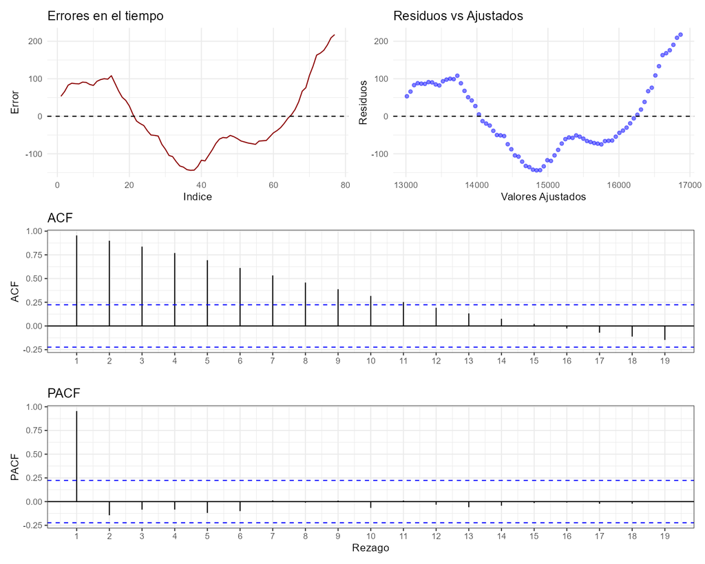

Tendencia Lineal: diagnóstico de los residuos

En este ejemplo los errores de un paso son los residuos de la regresión, así que las pruebas sirven a la vez para validar el método y para revisar los supuestos del modelo de regresión. Para la varianza constante se usa el panel de residuos contra valores ajustados. Los residuos no se dispersan al azar alrededor de cero: forman una onda suave, positivos en los valores ajustados bajos, negativos en los intermedios y de nuevo positivos y crecientes en los más altos. No aparece un embudo que indique varianza creciente, pero el patrón sistemático muestra que la población no creció exactamente en línea recta, y que al final del tramo de estimación la serie ya iba por encima de la recta. La ACF de los residuos decae despacio y la PACF solo tiene el primer rezago significativo, la forma típica de residuos con dependencia de tipo autorregresivo de primer orden.

**Contraste individual de las autocorrelaciones de los residuos**

1. *Hipótesis:* para cada rezago $h = 1, \ldots, 19$, $H_0: \rho_h = 0$ frente a $H_1: \rho_h \neq 0$.
2. *Estadístico:* $r_h = c_h / c_0$, con $c_h = n^{-1}\sum_{t=1}^{n-h}(x_t - \bar x)(x_{t+h} - \bar x)$. Por el resultado de Bartlett, bajo ruido blanco $r_h \approx N(0, 1/n)$, con $n = 77$.
3. *Región de rechazo al 5%:* $|r_h| > z_{0.975}/\sqrt{n} = 1.96/\sqrt{77} = 0.2234$.
4. *Valores observados:* la tabla muestra $r_h$, $z = r_h\sqrt{n}$ y su valor p en los rezagos que sostienen la lectura.
5. *Decisión:* se rechaza $H_0$ en los rezagos 1, 2, 3, 4, 5, 6, 7, 8, 9, 10, 11 y no se rechaza en los demás de los 19 examinados.
6. *Lectura:* los residuos tienen autocorrelación positiva fuerte en muchos rezagos: la población no crece exactamente en línea recta, sino con ondas largas alrededor de la recta que la tendencia no captura.

| Rezago $h$ | $r_h$ | $z$ | Valor p | Decisión |
| --- | --- | --- | --- | --- |
| 1 | 0.9547 | 8.377 | < 0.0001 | Se rechaza |
| 2 | 0.8987 | 7.886 | < 0.0001 | Se rechaza |
| 3 | 0.8368 | 7.342 | < 0.0001 | Se rechaza |
| 4 | 0.7693 | 6.751 | < 0.0001 | Se rechaza |
| 5 | 0.6937 | 6.087 | < 0.0001 | Se rechaza |
| 6 | 0.6115 | 5.366 | < 0.0001 | Se rechaza |

**Prueba t de media cero de los errores** ($N = 77$ errores)

1. *Hipótesis:* $H_0: \mu_e = 0$ frente a $H_1: \mu_e \neq 0$.
2. *Estadístico:* $t = \sqrt{N}\,\bar e / s_e$. Bajo $H_0$, $t \sim t_{N-1} = t_{76}$.
3. *Región de rechazo al 5%:* $|t| > t_{0.975;\,76} = 1.992$.
4. *Valor observado:* $t = -2.67 \times 10^{-13}$, valor p $= 1.0000$.
5. *Decisión:* No se rechaza $H_0$ al 5%.
6. *Lectura:* la media de los residuos es cero, lo cual está garantizado por construcción en una regresión con intercepto.

**Prueba de Ljung-Box sobre los residuos**

1. *Hipótesis:* $H_0: \rho_1 = \cdots = \rho_{19} = 0$ frente a $H_1$: al menos un $\rho_h \neq 0$ con $h \le 19$.
2. *Estadístico:* $Q_m = T(T+2)\sum_{h=1}^{m} r_h^2/(T-h)$, con $T = 77$ y $m = 19$. Bajo $H_0$, $Q_m \sim \chi^2_{m-p}$, con $p = 2$ parámetros estimados, es decir $\chi^2_{17}$.
3. *Región de rechazo al 5%:* $Q_m > \chi^2_{0.95;\,17} = 27.587$.
4. *Valor observado:* $Q_m = 399.468$, valor p $< 0.0001$.
5. *Decisión:* Se rechaza $H_0$ al 5%.
6. *Lectura:* los residuos no son independientes; queda estructura sin capturar.

**Prueba de Jarque-Bera** ($N = 77$ errores)

1. *Hipótesis:* $H_0$: los errores son normales ($A = 0$ y $K = 3$) frente a $H_1$: no son normales.
2. *Estadístico:* $JB = \frac{N}{6}\left[A^2 + \frac{(K-3)^2}{4}\right]$, con asimetría $A = 0.402$ y curtosis $K = 2.180$. Bajo $H_0$, $JB \sim \chi^2_2$ de forma asintótica.
3. *Región de rechazo al 5%:* $JB > \chi^2_{0.95;\,2} = 5.991$.
4. *Valor observado:* $JB = 4.236$, valor p $= 0.1203$.
5. *Decisión:* No se rechaza $H_0$ al 5%.
6. *Lectura:* los residuos son compatibles con una distribución normal.

**Prueba de Durbin-Watson sobre los residuos de la regresión** ($T = 77$, $k' = 1$)

1. *Hipótesis:* $H_0: \rho_1 = 0$ frente a $H_1: \rho_1 > 0$ (y $H_1: \rho_1 < 0$ usando $4 - d$).
2. *Estadístico:* $d = \sum_{t=2}^{T}(\hat\varepsilon_t - \hat\varepsilon_{t-1})^2 / \sum_{t=1}^{T}\hat\varepsilon_t^2$. Su distribución bajo $H_0$ depende de la matriz $X$, por lo que no tiene grados de libertad ni un valor p general; Durbin y Watson la acotan con $d_L$ y $d_U$, que dependen de $T$ y del número $k'$ de regresores sin contar el intercepto.
3. *Región de rechazo al 5%:* tabla de Savin y White (1977), fila $T = 75$ y $k' = 1$: $d_L = 1.598$ y $d_U = 1.652$. Se rechaza si $d < d_L$, la prueba no concluye si $d_L \le d \le d_U$ y no se rechaza si $d_U < d < 4 - d_U$.
4. *Valor observado:* $d = 0.017$; no hay valor p, por lo explicado en el paso 2.
5. *Decisión:* Se rechaza $H_0$ a favor de autocorrelación positiva de primer orden.
6. *Lectura:* hay autocorrelación positiva de primer orden muy fuerte, con $r_1 \approx 1 - d/2 = 0.991$. La tabla no tiene la fila $T = 77$ y se usa la inmediatamente inferior; con un $d$ tan pequeño la decisión no depende de esa elección.

### Pronóstico

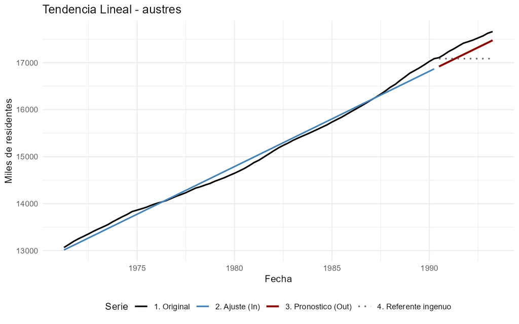

Tendencia Lineal: ajuste y pronóstico sobre el tramo de validación

### Conclusión

Se ajustó por mínimos cuadrados la recta $\hat T_t = 12963.29 + 50.707\,t$, con ambos coeficientes significativos usando errores robustos y $R^2 = 0.9931$. En validación ($h = 12$) su MAD fue 210.08 miles de residentes, frente a 322.04 del ingenuo, con MAPE de 1.21%. Los residuos cumplen media cero y normalidad ($JB = 4.236$), pero tienen autocorrelación fuerte según Ljung-Box ($Q = 399.47$) y Durbin-Watson ($d = 0.017$).

### Recomendación

Este pronóstico sirve a una oficina de planeación que necesite proyecciones de población para servicios públicos. Con un MAPE de 1.21% es razonable hasta los 12 trimestres validados, es decir, tres años. Su límite es que supone un crecimiento constante e indefinido, y la fuerte autocorrelación de los residuos hace que los errores no se compensen entre trimestres: en validación, el mayor error absoluto fue de 242.2 miles de residentes.

## 6. Tendencia Cuadrática

```r
ejecutar_protocolo("airmiles", datasets::airmiles,
                   "F.A.A. Statistical Handbook of Aviation",
                   "Millas-pasajero (millones)", "ajustar_tendencia", "Tendencia Cuadratica",
                   p_params = 3, prefijo = "06", es_tendencia = TRUE, tipo_tend = "cuadratica",
                   dL = 1.100, dU = 1.537)
```

### Descripción de la serie

```r
ej <- resultados$ej06
c(N = ej$N, frecuencia = ej$frecuencia)
```

```
         N frecuencia
        24          1
```

```r
c(inicio = ej$fecha_ini, fin = ej$fecha_fin)
```

```
      inicio          fin
"1937-01-01" "1960-01-01"
```

La serie `airmiles` registra las millas-pasajero de ingresos voladas por las aerolíneas comerciales de Estados Unidos cada año. Fuente: F.A.A. Statistical Handbook of Aviation. Unidad: millas-pasajero (millones). Frecuencia anual, de 1937 a 1960, con $N = 24$ observaciones.

### Patrón de la serie

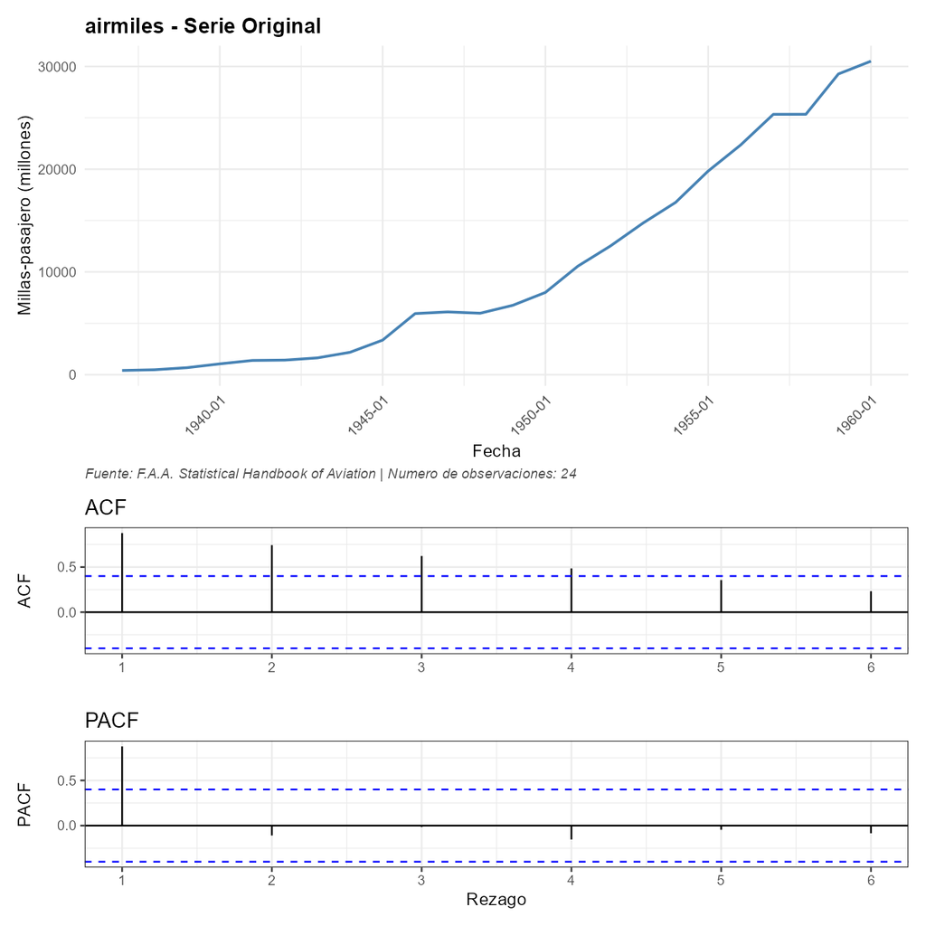

airmiles: serie original, ACF y PACF

El tráfico aéreo no solo crece, sino que crece cada vez más rápido: la curva es convexa, con incrementos anuales que aumentan con el tiempo. Una pendiente que cambia de forma sostenida es el supuesto de la tendencia cuadrática, cuyo término $\beta_2 t^2$ modela esa aceleración.

**Contraste individual de las autocorrelaciones de la serie**

1. *Hipótesis:* para cada rezago $h = 1, \ldots, 6$, $H_0: \rho_h = 0$ frente a $H_1: \rho_h \neq 0$.
2. *Estadístico:* $r_h = c_h / c_0$, con $c_h = n^{-1}\sum_{t=1}^{n-h}(x_t - \bar x)(x_{t+h} - \bar x)$. Por el resultado de Bartlett, bajo ruido blanco $r_h \approx N(0, 1/n)$, con $n = 24$.
3. *Región de rechazo al 5%:* $|r_h| > z_{0.975}/\sqrt{n} = 1.96/\sqrt{24} = 0.4001$.
4. *Valores observados:* la tabla muestra $r_h$, $z = r_h\sqrt{n}$ y su valor p en los rezagos que sostienen la lectura.
5. *Decisión:* se rechaza $H_0$ en los rezagos 1, 2, 3, 4 y no se rechaza en los demás de los 6 examinados.
6. *Lectura:* las primeras autocorrelaciones son positivas, significativas y decrecen despacio, como corresponde a una serie dominada por una tendencia. Con solo 24 observaciones, el número de rezagos examinados es $m = \lfloor 24/4 \rfloor = 6$.

| Rezago $h$ | $r_h$ | $z$ | Valor p | Decisión |
| --- | --- | --- | --- | --- |
| 1 | 0.8761 | 4.292 | < 0.0001 | Se rechaza |
| 2 | 0.7422 | 3.636 | 0.0003 | Se rechaza |
| 3 | 0.6221 | 3.048 | 0.0023 | Se rechaza |
| 4 | 0.4849 | 2.375 | 0.0175 | Se rechaza |

**Prueba de Ljung-Box sobre la serie**

1. *Hipótesis:* $H_0: \rho_1 = \cdots = \rho_{6} = 0$ frente a $H_1$: al menos un $\rho_h \neq 0$ con $h \le 6$.
2. *Estadístico:* $Q_m = T(T+2)\sum_{h=1}^{m} r_h^2/(T-h)$, con $T = 24$ y $m = 6$. Bajo $H_0$, $Q_m \sim \chi^2_{m-p}$, con $p = 0$ parámetros estimados, es decir $\chi^2_{6}$.
3. *Región de rechazo al 5%:* $Q_m > \chi^2_{0.95;\,6} = 12.592$.
4. *Valor observado:* $Q_m = 61.307$, valor p $< 0.0001$.
5. *Decisión:* Se rechaza $H_0$ al 5%.
6. *Lectura:* la serie tiene una dependencia temporal fuerte, producida por su tendencia.

### Partición y ajuste

Con $T = 24$, el tramo de validación son las últimas $h = \lfloor 0.2 \times 24 \rfloor = 4$ observaciones y el ajuste usa las primeras 20. La tendencia $T_t = \beta_0 + \beta_1 t + \beta_2 t^2$ se estima con las ecuaciones normales y no requiere `optimizar()`.

```r
round(ej$parametros$tabla, 4)
```

```
       Estimacion   SE_OLS SE_Robusto   t_OLS  p_OLS t_Robusto p_Robusto
beta_0  1420.1246 554.8976   517.1624  2.5593 0.0203    2.7460    0.0138
beta_1  -473.9304 121.6976   149.3568 -3.8943 0.0012   -3.1731    0.0056
beta_2    74.3292   5.6291     6.8758 13.2045 0.0000   10.8103    0.0000
```

```r
c(R2 = ej$parametros$R2, sigma2 = ej$parametros$sigma2, DW = ej$parametros$DW,
  rezagos_HAC = ej$parametros$rezagos_HAC)
```

```
          R2       sigma2           DW  rezagos_HAC
9.894001e-01 5.562900e+05 8.488541e-01 2.000000e+00
```

La curva ajustada explica el 98.94% de la variación. Los residuos tienen autocorrelación positiva (se muestra en la validación), y por eso los errores estándar ordinarios no son confiables: tratan como independientes residuos que se parecen entre sí y subestiman la incertidumbre. Aquí el error estándar robusto de $\hat\beta_2$ es 1.22 veces el ordinario, así que las pruebas se hacen con los robustos.

**Prueba t sobre $\beta_0$ con error estándar robusto**

1. *Hipótesis:* $H_0: \beta_0 = 0$ frente a $H_1: \beta_0 \neq 0$.
2. *Estadístico:* $t = \hat\beta_0 / \widehat{EE}_{HAC}(\hat\beta_0)$, con error estándar robusto de núcleo de Bartlett y 2 rezagos. Bajo $H_0$, $t \sim t_{T-p} = t_{17}$ de forma aproximada.
3. *Región de rechazo al 5%:* $|t| > t_{0.975;\,17} = 2.110$.
4. *Valor observado:* $\hat\beta_0 = 1420.1246$, $\widehat{EE}_{HAC} = 517.1624$, $t = 2.746$, valor p $= 0.0138$.
5. *Decisión:* Se rechaza $H_0$ al 5%.
6. *Lectura:* el intercepto es significativo al 5%.

**Prueba t sobre $\beta_1$ con error estándar robusto**

1. *Hipótesis:* $H_0: \beta_1 = 0$ frente a $H_1: \beta_1 \neq 0$.
2. *Estadístico:* $t = \hat\beta_1 / \widehat{EE}_{HAC}(\hat\beta_1)$, con error estándar robusto de núcleo de Bartlett y 2 rezagos. Bajo $H_0$, $t \sim t_{T-p} = t_{17}$ de forma aproximada.
3. *Región de rechazo al 5%:* $|t| > t_{0.975;\,17} = 2.110$.
4. *Valor observado:* $\hat\beta_1 = -473.9304$, $\widehat{EE}_{HAC} = 149.3568$, $t = -3.173$, valor p $= 0.0056$.
5. *Decisión:* Se rechaza $H_0$ al 5%.
6. *Lectura:* el término lineal es significativo y negativo. No tiene una lectura propia: junto con la curvatura, ubica el mínimo de la parábola en los primeros años del período, y a partir de allí domina la aceleración.

**Prueba t sobre $\beta_2$ con error estándar robusto**

1. *Hipótesis:* $H_0: \beta_2 = 0$ frente a $H_1: \beta_2 \neq 0$.
2. *Estadístico:* $t = \hat\beta_2 / \widehat{EE}_{HAC}(\hat\beta_2)$, con error estándar robusto de núcleo de Bartlett y 2 rezagos. Bajo $H_0$, $t \sim t_{T-p} = t_{17}$ de forma aproximada.
3. *Región de rechazo al 5%:* $|t| > t_{0.975;\,17} = 2.110$.
4. *Valor observado:* $\hat\beta_2 = 74.3292$, $\widehat{EE}_{HAC} = 6.8758$, $t = 10.810$, valor p $< 0.0001$.
5. *Decisión:* Se rechaza $H_0$ al 5%.
6. *Lectura:* la curvatura es positiva y muy significativa: el tráfico aéreo se acelera año tras año, que es justamente lo que justifica la tendencia cuadrática frente a una recta.

### Medidas de precisión

```r
round(rbind(metodo_estimacion    = ej$medidas_in,
            metodo_validacion    = ej$medidas_out,
            referente_validacion = ej$medidas_referente_out), 4)
```

```
                            MSE       MAD    MAPE   MASE
metodo_estimacion      472846.5  518.4537 20.5654 0.4436
metodo_validacion     2416497.7 1408.8869  5.0918 1.2055
referente_validacion 32979149.5 5254.5000 18.4572 4.4959
```

En validación, la tendencia cuadrática obtiene un MAD de 1408.9 millones de millas-pasajero frente a 5254.5 del ingenuo, un error 73.2% menor, con MAPE de 5.09%. El MASE de 1.205 es mayor que 1 porque se escala con el cambio de un año a otro en el tramo de estimación, cuando los valores eran mucho más pequeños; frente al ingenuo en el mismo tramo de validación, la cuadrática es muy superior, porque el ingenuo congela el último valor en una serie que sigue acelerando.

### Validación de errores

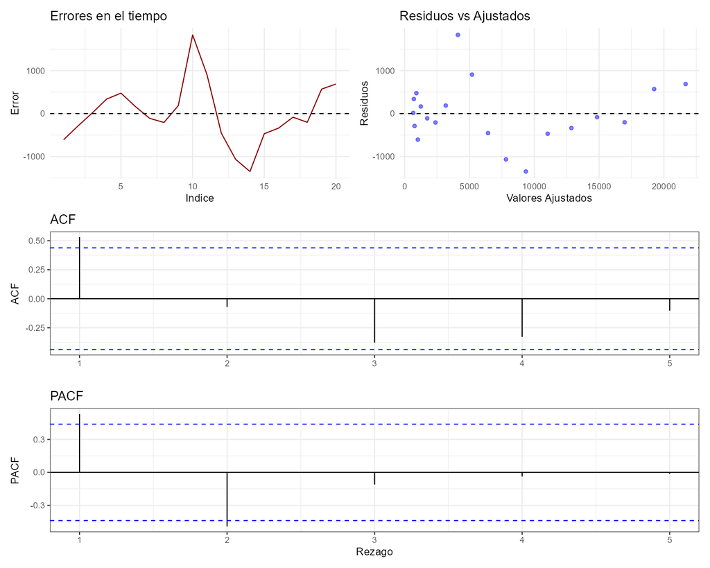

Tendencia Cuadrática: diagnóstico de los residuos

Los errores de un paso son los residuos de la regresión. En el panel de residuos contra valores ajustados no aparece un embudo: la dispersión no crece de forma clara con el nivel ajustado. El residuo más grande corresponde al décimo año del tramo, 1946, cuando el tráfico aéreo saltó con el fin de la Segunda Guerra Mundial, y es seguido por varios años de residuos negativos. Con solo 20 residuos, esta lectura de la varianza es necesariamente aproximada.

**Contraste individual de las autocorrelaciones de los residuos**

1. *Hipótesis:* para cada rezago $h = 1, \ldots, 5$, $H_0: \rho_h = 0$ frente a $H_1: \rho_h \neq 0$.
2. *Estadístico:* $r_h = c_h / c_0$, con $c_h = n^{-1}\sum_{t=1}^{n-h}(x_t - \bar x)(x_{t+h} - \bar x)$. Por el resultado de Bartlett, bajo ruido blanco $r_h \approx N(0, 1/n)$, con $n = 20$.
3. *Región de rechazo al 5%:* $|r_h| > z_{0.975}/\sqrt{n} = 1.96/\sqrt{20} = 0.4383$.
4. *Valores observados:* la tabla muestra $r_h$, $z = r_h\sqrt{n}$ y su valor p en los rezagos que sostienen la lectura.
5. *Decisión:* se rechaza $H_0$ en los rezagos 1 y no se rechaza en los demás de los 5 examinados.
6. *Lectura:* el primer rezago queda fuera de la banda: residuos de años consecutivos tienden a tener el mismo signo, lo que indica que la parábola no sigue del todo la forma de la curva.

| Rezago $h$ | $r_h$ | $z$ | Valor p | Decisión |
| --- | --- | --- | --- | --- |
| 1 | 0.5309 | 2.374 | 0.0176 | Se rechaza |

**Prueba t de media cero de los errores** ($N = 20$ errores)

1. *Hipótesis:* $H_0: \mu_e = 0$ frente a $H_1: \mu_e \neq 0$.
2. *Estadístico:* $t = \sqrt{N}\,\bar e / s_e$. Bajo $H_0$, $t \sim t_{N-1} = t_{19}$.
3. *Región de rechazo al 5%:* $|t| > t_{0.975;\,19} = 2.093$.
4. *Valor observado:* $t = -2.49 \times 10^{-15}$, valor p $= 1.0000$.
5. *Decisión:* No se rechaza $H_0$ al 5%.
6. *Lectura:* la media de los residuos es cero, lo cual está garantizado por construcción en una regresión con intercepto.

**Prueba de Ljung-Box sobre los residuos**

1. *Hipótesis:* $H_0: \rho_1 = \cdots = \rho_{5} = 0$ frente a $H_1$: al menos un $\rho_h \neq 0$ con $h \le 5$.
2. *Estadístico:* $Q_m = T(T+2)\sum_{h=1}^{m} r_h^2/(T-h)$, con $T = 20$ y $m = 5$. Bajo $H_0$, $Q_m \sim \chi^2_{m-p}$, con $p = 3$ parámetros estimados, es decir $\chi^2_{2}$.
3. *Región de rechazo al 5%:* $Q_m > \chi^2_{0.95;\,2} = 5.991$.
4. *Valor observado:* $Q_m = 13.633$, valor p $= 0.0011$.
5. *Decisión:* Se rechaza $H_0$ al 5%.
6. *Lectura:* los residuos no son independientes. Con 3 coeficientes estimados y $m = 5$, la prueba tiene solo 2 grados de libertad.

**Prueba de Jarque-Bera** ($N = 20$ errores)

1. *Hipótesis:* $H_0$: los errores son normales ($A = 0$ y $K = 3$) frente a $H_1$: no son normales.
2. *Estadístico:* $JB = \frac{N}{6}\left[A^2 + \frac{(K-3)^2}{4}\right]$, con asimetría $A = 0.524$ y curtosis $K = 3.864$. Bajo $H_0$, $JB \sim \chi^2_2$ de forma asintótica.
3. *Región de rechazo al 5%:* $JB > \chi^2_{0.95;\,2} = 5.991$.
4. *Valor observado:* $JB = 1.536$, valor p $= 0.4640$.
5. *Decisión:* No se rechaza $H_0$ al 5%. Advertencia: la prueba es asintótica y con $N = 20$ errores su aproximación es pobre, así que esta decisión es solo indicativa.
6. *Lectura:* no hay evidencia contra la normalidad de los residuos, aunque con tan pocos datos la prueba tiene poca potencia.

**Prueba de Durbin-Watson sobre los residuos de la regresión** ($T = 20$, $k' = 2$)

1. *Hipótesis:* $H_0: \rho_1 = 0$ frente a $H_1: \rho_1 > 0$ (y $H_1: \rho_1 < 0$ usando $4 - d$).
2. *Estadístico:* $d = \sum_{t=2}^{T}(\hat\varepsilon_t - \hat\varepsilon_{t-1})^2 / \sum_{t=1}^{T}\hat\varepsilon_t^2$. Su distribución bajo $H_0$ depende de la matriz $X$, por lo que no tiene grados de libertad ni un valor p general; Durbin y Watson la acotan con $d_L$ y $d_U$, que dependen de $T$ y del número $k'$ de regresores sin contar el intercepto.
3. *Región de rechazo al 5%:* tabla de Savin y White (1977), fila $T = 20$ y $k' = 2$: $d_L = 1.100$ y $d_U = 1.537$. Se rechaza si $d < d_L$, la prueba no concluye si $d_L \le d \le d_U$ y no se rechaza si $d_U < d < 4 - d_U$.
4. *Valor observado:* $d = 0.849$; no hay valor p, por lo explicado en el paso 2.
5. *Decisión:* Se rechaza $H_0$ a favor de autocorrelación positiva de primer orden.
6. *Lectura:* hay autocorrelación positiva de primer orden, con $r_1 \approx 0.576$, coherente con el primer rezago fuera de la banda.

### Pronóstico

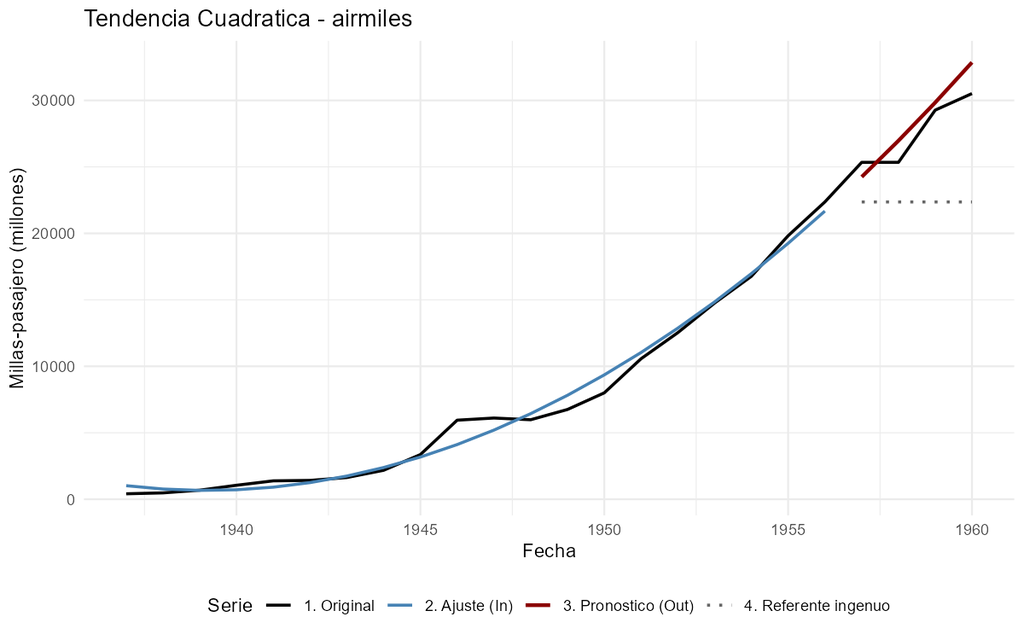

Tendencia Cuadrática: ajuste y pronóstico sobre el tramo de validación

### Conclusión

Se ajustó por mínimos cuadrados la parábola $\hat T_t = 1420.1 -473.9\,t + 74.33\,t^2$, con los tres coeficientes significativos usando errores robustos y $R^2 = 0.9894$. En validación ($h = 4$) su MAD fue 1408.9 millones de millas-pasajero, frente a 5254.5 del ingenuo, con MAPE de 5.09%. Los residuos tienen media cero y no se rechaza su normalidad ($JB = 1.536$, con solo 20 residuos), pero tienen autocorrelación según Ljung-Box ($Q = 13.633$) y Durbin-Watson ($d = 0.849$).

### Recomendación

Este pronóstico sirve a una aerolínea o a una autoridad aeroportuaria de la época que planee compras de flota o ampliaciones para los años siguientes. Es razonable hasta los 4 años validados. Su límite es que una parábola crece sin freno: si la aceleración del tráfico se detiene, el pronóstico la sobreestimará cada vez más. Incluso dentro del horizonte validado, el mayor error absoluto fue de 2345.4 millones de millas-pasajero en un solo año, el 7.7% del valor observado ese año.

## 7. Tendencia Exponencial

```r
ejecutar_protocolo("JohnsonJohnson", datasets::JohnsonJohnson,
                   "Shumway, R. H. and Stoffer, D. S. (2000) Time Series Analysis and its Applications. Second Edition. Springer. Example 1.1",
                   "Ganancia por accion (dolares)", "ajustar_tendencia", "Tendencia Exponencial",
                   p_params = 2, prefijo = "07", es_tendencia = TRUE, tipo_tend = "exponencial",
                   corregir_ses = TRUE, dL = 1.583, dU = 1.641)
```

### Descripción de la serie

```r
ej <- resultados$ej07
c(N = ej$N, frecuencia = ej$frecuencia)
```

```
         N frecuencia
        84          4
```

```r
c(inicio = ej$fecha_ini, fin = ej$fecha_fin)
```

```
      inicio          fin
"1960-01-01" "1980-10-01"
```

La serie `JohnsonJohnson` registra la ganancia trimestral por acción de la empresa Johnson & Johnson. Fuente: Shumway, R. H. and Stoffer, D. S. (2000) Time Series Analysis and its Applications. Second Edition. Springer. Example 1.1. Unidad: ganancia por accion (dolares). Frecuencia trimestral, de 1960-T1 a 1980-T4, con $N = 84$ observaciones.

### Patrón de la serie

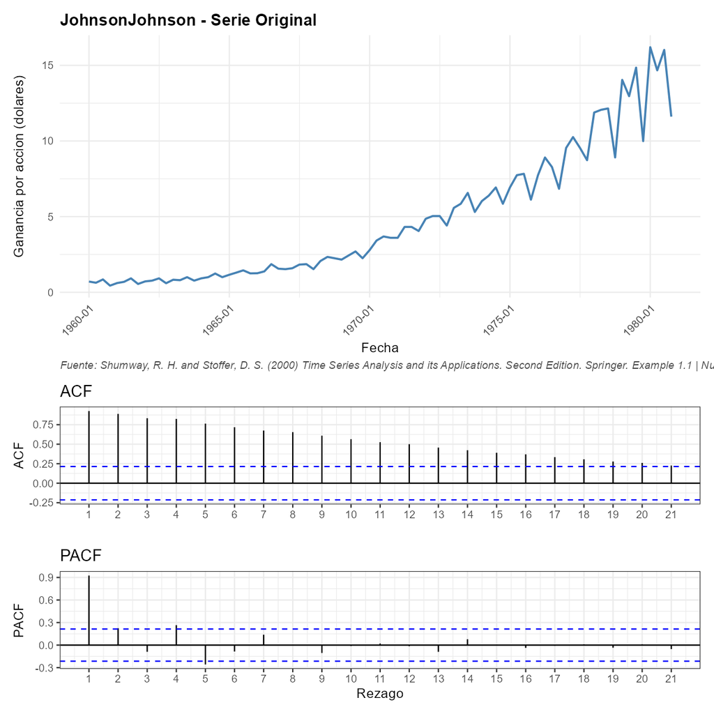

JohnsonJohnson: serie original, ACF y PACF

La ganancia crece a una tasa porcentual aproximadamente constante: la curva se empina con el tiempo y la amplitud de sus oscilaciones aumenta con el nivel. Ese es el supuesto de la tendencia exponencial $T_t = \beta_0\beta_1^t$, que al tomar logaritmos se vuelve lineal y estabiliza la varianza. La serie también tiene un patrón trimestral que se repite cada año; la tendencia exponencial no lo modela, y esa limitación se evalúa en la validación.

**Contraste individual de las autocorrelaciones de la serie**

1. *Hipótesis:* para cada rezago $h = 1, \ldots, 21$, $H_0: \rho_h = 0$ frente a $H_1: \rho_h \neq 0$.
2. *Estadístico:* $r_h = c_h / c_0$, con $c_h = n^{-1}\sum_{t=1}^{n-h}(x_t - \bar x)(x_{t+h} - \bar x)$. Por el resultado de Bartlett, bajo ruido blanco $r_h \approx N(0, 1/n)$, con $n = 84$.
3. *Región de rechazo al 5%:* $|r_h| > z_{0.975}/\sqrt{n} = 1.96/\sqrt{84} = 0.2138$.
4. *Valores observados:* la tabla muestra $r_h$, $z = r_h\sqrt{n}$ y su valor p en los rezagos que sostienen la lectura.
5. *Decisión:* se rechaza $H_0$ en los rezagos 1, 2, 3, 4, 5, 6, 7, 8, 9, 10, 11, 12, 13, 14, 15, 16, 17, 18, 19, 20, 21 y no se rechaza en los demás de los 21 examinados.
6. *Lectura:* todas las autocorrelaciones examinadas son positivas, significativas y decaen lentamente, el correlograma típico de una serie dominada por una tendencia.

| Rezago $h$ | $r_h$ | $z$ | Valor p | Decisión |
| --- | --- | --- | --- | --- |
| 1 | 0.9251 | 8.479 | < 0.0001 | Se rechaza |
| 4 | 0.8241 | 7.553 | < 0.0001 | Se rechaza |
| 8 | 0.6544 | 5.997 | < 0.0001 | Se rechaza |
| 12 | 0.5004 | 4.586 | < 0.0001 | Se rechaza |
| 16 | 0.3699 | 3.390 | 0.0007 | Se rechaza |
| 21 | 0.2260 | 2.072 | 0.0383 | Se rechaza |

**Prueba de Ljung-Box sobre la serie**

1. *Hipótesis:* $H_0: \rho_1 = \cdots = \rho_{21} = 0$ frente a $H_1$: al menos un $\rho_h \neq 0$ con $h \le 21$.
2. *Estadístico:* $Q_m = T(T+2)\sum_{h=1}^{m} r_h^2/(T-h)$, con $T = 84$ y $m = 21$. Bajo $H_0$, $Q_m \sim \chi^2_{m-p}$, con $p = 0$ parámetros estimados, es decir $\chi^2_{21}$.
3. *Región de rechazo al 5%:* $Q_m > \chi^2_{0.95;\,21} = 32.671$.
4. *Valor observado:* $Q_m = 685.351$, valor p $< 0.0001$.
5. *Decisión:* Se rechaza $H_0$ al 5%.
6. *Lectura:* la dependencia temporal es muy fuerte, producida por el crecimiento sostenido de la serie.

### Partición y ajuste

La serie es estacional, así que el referente es el ingenuo estacional $\hat Y_{T+h} = Y_{T+h-4\lceil h/4 \rceil}$. El tramo de validación son las últimas $h = 12$ observaciones, tres ciclos completos, y el ajuste usa las primeras 72. La tendencia se estima sobre $\ln Y_t = a + \theta t + \varepsilon_t$ con las ecuaciones normales, y $\hat\beta_0 = e^{\hat a}$, $\hat\beta_1 = e^{\hat\theta}$. No requiere `optimizar()`.

```r
round(ej$parametros$tabla, 4)
```

```
      Estimacion SE_OLS SE_Robusto    t_OLS p_OLS t_Robusto p_Robusto
a        -0.6968 0.0360     0.0426 -19.3737     0  -16.3663         0
theta     0.0428 0.0009     0.0010  49.9431     0   42.9616         0
```

```r
c(beta0 = ej$parametros$beta0, beta1 = ej$parametros$beta1)
```

```
    beta0     beta1
0.4981558 1.0436966
```

```r
c(R2 = ej$parametros$R2, sigma2 = ej$parametros$sigma2, DW = ej$parametros$DW,
  rezagos_HAC = ej$parametros$rezagos_HAC)
```

```
         R2      sigma2          DW rezagos_HAC
 0.97270223  0.02280532  1.68983925  3.00000000
```

El pronóstico $e^{\hat a + \hat\theta t}$ estima la mediana condicional de $Y_t$, no su media, porque la exponencial de la media de $\ln Y_t$ es menor que la media de $Y_t$. Por eso se aplicó la corrección de sesgo, que multiplica el pronóstico por $e^{\hat\sigma^2/2} = 1.0115$, un aumento de 1.15%.

Los residuos de la regresión en logaritmos tienen autocorrelación positiva en los rezagos estacionales (se muestra más abajo), así que los errores estándar ordinarios subestiman la incertidumbre y las pruebas se hacen con los robustos. El error robusto de $\hat\theta$ es 1.16 veces el ordinario.

**Prueba t sobre $a$ con error estándar robusto**

1. *Hipótesis:* $H_0: a = 0$ frente a $H_1: a \neq 0$.
2. *Estadístico:* $t = \hata / \widehat{EE}_{HAC}(\hata)$, con error estándar robusto de núcleo de Bartlett y 3 rezagos. Bajo $H_0$, $t \sim t_{T-p} = t_{70}$ de forma aproximada.
3. *Región de rechazo al 5%:* $|t| > t_{0.975;\,70} = 1.994$.
4. *Valor observado:* $\hata = -0.6968$, $\widehat{EE}_{HAC} = 0.0426$, $t = -16.366$, valor p $< 0.0001$.
5. *Decisión:* Se rechaza $H_0$ al 5%.
6. *Lectura:* el intercepto en logaritmos es significativo; equivale a $\hat\beta_0 = e^{\hat a} = 0.498$ dólares al inicio del tramo.

**Prueba t sobre $\theta$ con error estándar robusto**

1. *Hipótesis:* $H_0: \theta = 0$ frente a $H_1: \theta \neq 0$.
2. *Estadístico:* $t = \hat\theta / \widehat{EE}_{HAC}(\hat\theta)$, con error estándar robusto de núcleo de Bartlett y 3 rezagos. Bajo $H_0$, $t \sim t_{T-p} = t_{70}$ de forma aproximada.
3. *Región de rechazo al 5%:* $|t| > t_{0.975;\,70} = 1.994$.
4. *Valor observado:* $\hat\theta = 0.0428$, $\widehat{EE}_{HAC} = 0.0010$, $t = 42.962$, valor p $< 0.0001$.
5. *Decisión:* Se rechaza $H_0$ al 5%.
6. *Lectura:* la tasa de crecimiento es significativa: $\hat\beta_1 = e^{\hat\theta} = 1.0437$, es decir, la ganancia por acción crece en promedio un 4.37% por trimestre.

### Supuestos de la regresión sobre los residuos de $\ln Y_t$

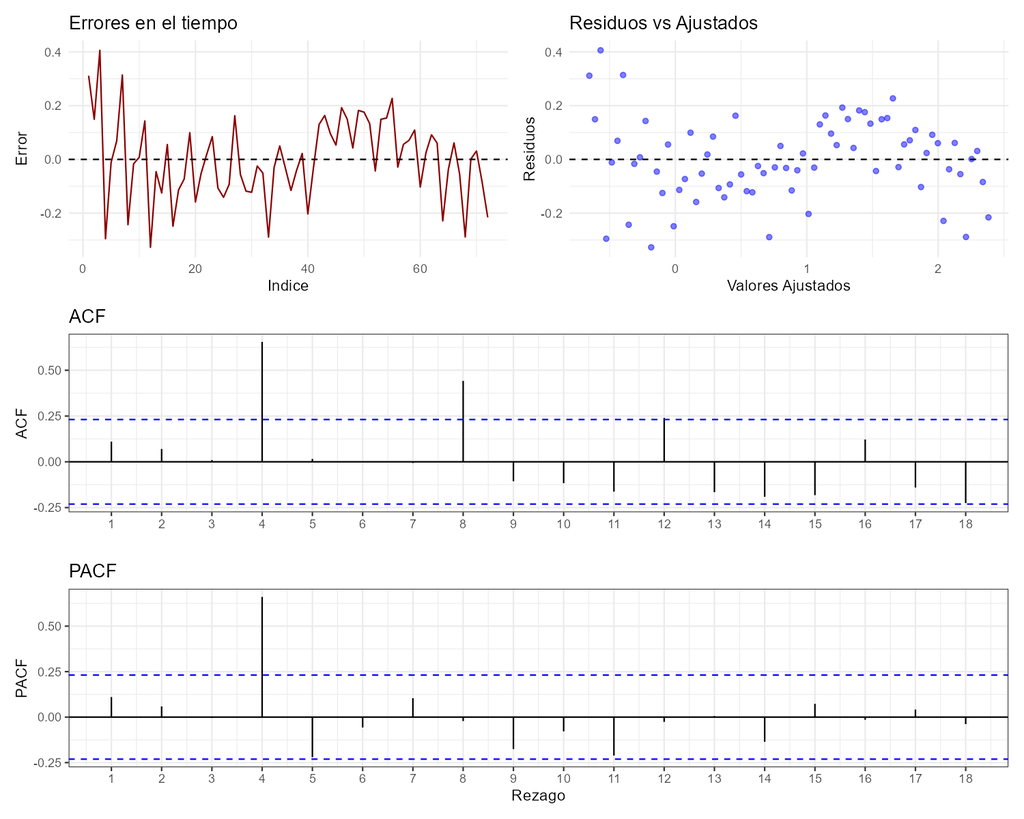

Tendencia Exponencial: diagnóstico de los residuos de la regresión en logaritmos

Como el modelo se ajusta en logaritmos, sus supuestos se revisan sobre los residuos de $\ln Y_t$. En el panel de residuos contra valores ajustados, los residuos se mantienen en una franja de ancho parecido a lo largo de todo el rango, con algo más de dispersión en los primeros valores: la escala logarítmica cumple su propósito de estabilizar la varianza, que en la escala original crecía con el nivel. En la ACF, los picos de los rezagos 4, 8 y 12 decrecen de forma regular, la huella de un patrón estacional que se repite cada año.

**Contraste individual de las autocorrelaciones de los residuos de la regresión en logaritmos**

1. *Hipótesis:* para cada rezago $h = 1, \ldots, 18$, $H_0: \rho_h = 0$ frente a $H_1: \rho_h \neq 0$.
2. *Estadístico:* $r_h = c_h / c_0$, con $c_h = n^{-1}\sum_{t=1}^{n-h}(x_t - \bar x)(x_{t+h} - \bar x)$. Por el resultado de Bartlett, bajo ruido blanco $r_h \approx N(0, 1/n)$, con $n = 72$.
3. *Región de rechazo al 5%:* $|r_h| > z_{0.975}/\sqrt{n} = 1.96/\sqrt{72} = 0.2310$.
4. *Valores observados:* la tabla muestra $r_h$, $z = r_h\sqrt{n}$ y su valor p en los rezagos que sostienen la lectura.
5. *Decisión:* se rechaza $H_0$ en los rezagos 4, 8, 12 y no se rechaza en los demás de los 18 examinados.
6. *Lectura:* los rezagos significativos son el 4, el 8 y el 12, múltiplos de la frecuencia trimestral: es la estacionalidad que la tendencia exponencial no modela.

| Rezago $h$ | $r_h$ | $z$ | Valor p | Decisión |
| --- | --- | --- | --- | --- |
| 1 | 0.1101 | 0.934 | 0.3502 | No se rechaza |
| 4 | 0.6549 | 5.557 | < 0.0001 | Se rechaza |
| 8 | 0.4417 | 3.748 | 0.0002 | Se rechaza |
| 12 | 0.2397 | 2.034 | 0.0419 | Se rechaza |

**Prueba t de media cero de los errores** ($N = 72$ errores)

1. *Hipótesis:* $H_0: \mu_e = 0$ frente a $H_1: \mu_e \neq 0$.
2. *Estadístico:* $t = \sqrt{N}\,\bar e / s_e$. Bajo $H_0$, $t \sim t_{N-1} = t_{71}$.
3. *Región de rechazo al 5%:* $|t| > t_{0.975;\,71} = 1.994$.
4. *Valor observado:* $t = 4.88 \times 10^{-15}$, valor p $= 1.0000$.
5. *Decisión:* No se rechaza $H_0$ al 5%.
6. *Lectura:* la media de los residuos es cero, lo cual está garantizado por construcción en una regresión con intercepto.

**Prueba de Ljung-Box sobre los residuos de la regresión en logaritmos**

1. *Hipótesis:* $H_0: \rho_1 = \cdots = \rho_{18} = 0$ frente a $H_1$: al menos un $\rho_h \neq 0$ con $h \le 18$.
2. *Estadístico:* $Q_m = T(T+2)\sum_{h=1}^{m} r_h^2/(T-h)$, con $T = 72$ y $m = 18$. Bajo $H_0$, $Q_m \sim \chi^2_{m-p}$, con $p = 2$ parámetros estimados, es decir $\chi^2_{16}$.
3. *Región de rechazo al 5%:* $Q_m > \chi^2_{0.95;\,16} = 26.296$.
4. *Valor observado:* $Q_m = 77.970$, valor p $< 0.0001$.
5. *Decisión:* Se rechaza $H_0$ al 5%.
6. *Lectura:* los residuos no son independientes, por la estacionalidad que queda en ellos.

**Prueba de Jarque-Bera** ($N = 72$ errores)

1. *Hipótesis:* $H_0$: los errores son normales ($A = 0$ y $K = 3$) frente a $H_1$: no son normales.
2. *Estadístico:* $JB = \frac{N}{6}\left[A^2 + \frac{(K-3)^2}{4}\right]$, con asimetría $A = 0.022$ y curtosis $K = 3.020$. Bajo $H_0$, $JB \sim \chi^2_2$ de forma asintótica.
3. *Región de rechazo al 5%:* $JB > \chi^2_{0.95;\,2} = 5.991$.
4. *Valor observado:* $JB = 0.007$, valor p $= 0.9965$.
5. *Decisión:* No se rechaza $H_0$ al 5%.
6. *Lectura:* los residuos en logaritmos son claramente compatibles con la normalidad, lo que respalda el modelo log-lineal.

**Prueba de Durbin-Watson sobre los residuos de la regresión** ($T = 72$, $k' = 1$)

1. *Hipótesis:* $H_0: \rho_1 = 0$ frente a $H_1: \rho_1 > 0$ (y $H_1: \rho_1 < 0$ usando $4 - d$).
2. *Estadístico:* $d = \sum_{t=2}^{T}(\hat\varepsilon_t - \hat\varepsilon_{t-1})^2 / \sum_{t=1}^{T}\hat\varepsilon_t^2$. Su distribución bajo $H_0$ depende de la matriz $X$, por lo que no tiene grados de libertad ni un valor p general; Durbin y Watson la acotan con $d_L$ y $d_U$, que dependen de $T$ y del número $k'$ de regresores sin contar el intercepto.
3. *Región de rechazo al 5%:* tabla de Savin y White (1977), fila $T = 70$ y $k' = 1$: $d_L = 1.583$ y $d_U = 1.641$. Se rechaza si $d < d_L$, la prueba no concluye si $d_L \le d \le d_U$ y no se rechaza si $d_U < d < 4 - d_U$.
4. *Valor observado:* $d = 1.690$; no hay valor p, por lo explicado en el paso 2.
5. *Decisión:* No se rechaza $H_0$.
6. *Lectura:* no hay evidencia de autocorrelación de primer orden. Esto no contradice a Ljung-Box: Durbin-Watson solo examina el rezago 1, y la dependencia que queda está en los rezagos estacionales 4, 8 y 12. La tabla no tiene la fila $T = 72$ y se usa la inmediatamente inferior.

### Medidas de precisión

```r
round(rbind(metodo_estimacion    = ej$medidas_in,
            metodo_validacion    = ej$medidas_out,
            referente_validacion = ej$medidas_referente_out), 4)
```

```
                         MSE    MAD    MAPE   MASE
metodo_estimacion     0.3316 0.3630 12.0734 0.6914
metodo_validacion     8.3287 1.8826 16.9187 3.5860
referente_validacion 15.5810 3.4275 24.6506 6.5286
```

En validación, la tendencia exponencial obtiene un MAD de 1.883 dólares frente a 3.428 del ingenuo estacional, un error 45.1% menor, con MAPE de 16.92%. El MASE de 3.59 es mayor que 1 porque se escala con el error del ingenuo estacional en el tramo de estimación, cuando la ganancia era mucho menor; en el tramo de validación la serie creció tanto que repetir el año anterior se queda corto.

### Validación de errores

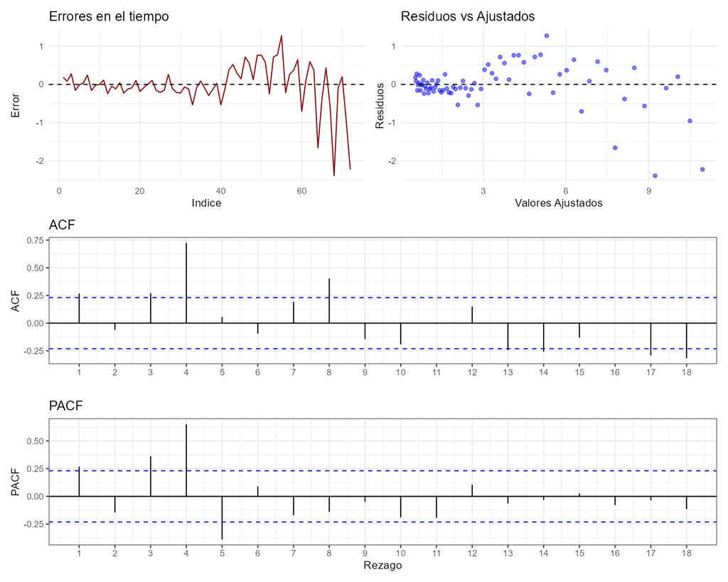

Tendencia Exponencial: diagnóstico de los errores de un paso en dólares

Los errores de un paso se evalúan en la escala original, en dólares por acción.

**Contraste individual de las autocorrelaciones de los errores**

1. *Hipótesis:* para cada rezago $h = 1, \ldots, 18$, $H_0: \rho_h = 0$ frente a $H_1: \rho_h \neq 0$.
2. *Estadístico:* $r_h = c_h / c_0$, con $c_h = n^{-1}\sum_{t=1}^{n-h}(x_t - \bar x)(x_{t+h} - \bar x)$. Por el resultado de Bartlett, bajo ruido blanco $r_h \approx N(0, 1/n)$, con $n = 72$.
3. *Región de rechazo al 5%:* $|r_h| > z_{0.975}/\sqrt{n} = 1.96/\sqrt{72} = 0.2310$.
4. *Valores observados:* la tabla muestra $r_h$, $z = r_h\sqrt{n}$ y su valor p en los rezagos que sostienen la lectura.
5. *Decisión:* se rechaza $H_0$ en los rezagos 1, 3, 4, 8, 13, 14, 17, 18 y no se rechaza en los demás de los 18 examinados.
6. *Lectura:* varios rezagos quedan fuera de la banda, entre ellos los estacionales 4 y 8: los errores repiten el patrón trimestral que el método no modela.

| Rezago $h$ | $r_h$ | $z$ | Valor p | Decisión |
| --- | --- | --- | --- | --- |
| 1 | 0.2683 | 2.277 | 0.0228 | Se rechaza |
| 3 | 0.2709 | 2.299 | 0.0215 | Se rechaza |
| 4 | 0.7243 | 6.146 | < 0.0001 | Se rechaza |
| 8 | 0.4027 | 3.417 | 0.0006 | Se rechaza |
| 13 | -0.2440 | -2.070 | 0.0385 | Se rechaza |
| 17 | -0.2926 | -2.483 | 0.0130 | Se rechaza |

**Prueba t de media cero de los errores** ($N = 72$ errores)

1. *Hipótesis:* $H_0: \mu_e = 0$ frente a $H_1: \mu_e \neq 0$.
2. *Estadístico:* $t = \sqrt{N}\,\bar e / s_e$. Bajo $H_0$, $t \sim t_{N-1} = t_{71}$.
3. *Región de rechazo al 5%:* $|t| > t_{0.975;\,71} = 1.994$.
4. *Valor observado:* $t = -0.370$, valor p $= 0.7127$.
5. *Decisión:* No se rechaza $H_0$ al 5%.
6. *Lectura:* los errores no están sesgados: la corrección de sesgo hace que el pronóstico no subestime la ganancia en promedio.

**Prueba de Ljung-Box sobre los errores**

1. *Hipótesis:* $H_0: \rho_1 = \cdots = \rho_{18} = 0$ frente a $H_1$: al menos un $\rho_h \neq 0$ con $h \le 18$.
2. *Estadístico:* $Q_m = T(T+2)\sum_{h=1}^{m} r_h^2/(T-h)$, con $T = 72$ y $m = 18$. Bajo $H_0$, $Q_m \sim \chi^2_{m-p}$, con $p = 2$ parámetros estimados, es decir $\chi^2_{16}$.
3. *Región de rechazo al 5%:* $Q_m > \chi^2_{0.95;\,16} = 26.296$.
4. *Valor observado:* $Q_m = 108.202$, valor p $< 0.0001$.
5. *Decisión:* Se rechaza $H_0$ al 5%.
6. *Lectura:* los errores no son independientes: queda la estructura estacional.

**Prueba de Jarque-Bera** ($N = 72$ errores)

1. *Hipótesis:* $H_0$: los errores son normales ($A = 0$ y $K = 3$) frente a $H_1$: no son normales.
2. *Estadístico:* $JB = \frac{N}{6}\left[A^2 + \frac{(K-3)^2}{4}\right]$, con asimetría $A = -1.746$ y curtosis $K = 8.730$. Bajo $H_0$, $JB \sim \chi^2_2$ de forma asintótica.
3. *Región de rechazo al 5%:* $JB > \chi^2_{0.95;\,2} = 5.991$.
4. *Valor observado:* $JB = 135.089$, valor p $< 0.0001$.
5. *Decisión:* Se rechaza $H_0$ al 5%.
6. *Lectura:* los errores en dólares no son normales: tienen colas muy pesadas, porque su tamaño crece con el nivel de la serie. Esta heterocedasticidad es la que el ajuste en logaritmos corrige.

**Prueba de Durbin-Watson** ($N = 72$ errores)

1. *Hipótesis:* $H_0: \rho_1 = 0$ frente a $H_1: \rho_1 \neq 0$.
2. *Estadístico:* $d = \sum_{t=2}^{N}(e_t - e_{t-1})^2 / \sum_{t=1}^{N} e_t^2 \approx 2(1 - r_1)$. Las cotas $d_L$ y $d_U$ solo aplican a residuos de una regresión; para los errores de un método se usa que, bajo $H_0$, $r_1 \approx N(0, 1/N)$, de modo que $z = (2 - d)\sqrt{N}/2 \approx N(0, 1)$.
3. *Región de rechazo al 5%:* $|z| > 1.96$, equivalente a $d < 1.538$ o $d > 2.462$.
4. *Valor observado:* $d = 1.256$, $z = 3.157$, valor p $= 0.0016$.
5. *Decisión:* Se rechaza $H_0$ al 5%.
6. *Lectura:* hay autocorrelación positiva de primer orden en los errores en dólares.

### Pronóstico

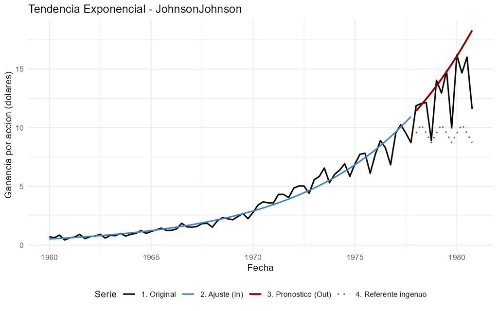

Tendencia Exponencial: ajuste y pronóstico sobre el tramo de validación

### Conclusión

Se ajustó la tendencia exponencial $\hat T_t = 0.498 \times 1.0437^t$ sobre los logaritmos, con corrección de sesgo, ambos coeficientes significativos con errores robustos y $R^2 = 0.9727$ en escala logarítmica. En validación ($h = 12$) su MAD fue 1.883 dólares, frente a 3.428 del ingenuo estacional, con MAPE de 16.92%. Los residuos en logaritmos son normales ($JB = 0.007$) pero conservan estacionalidad ($Q = 77.97$); los errores en dólares tienen media cero ($t = -0.370$), pero no son independientes ($Q = 108.20$) ni normales ($JB = 135.09$).

## 8. Holt Lineal

```r
ejecutar_protocolo("LakeHuron", datasets::LakeHuron,
                   "Brockwell, P. J. and Davis, R. A. (1991). Time Series and Forecasting Methods. Second edition. Springer, New York. Series A, page 555",
                   "Nivel del lago (pies)", "ajustar_holt", "Holt Lineal",
                   p_params = 2, prefijo = "08",
                   param_rejilla = expand.grid(alpha = seq(0.05, 0.95, by = 0.05),
                                               beta  = seq(0.05, 0.95, by = 0.05)))
```

### Descripción de la serie

```r
ej <- resultados$ej08
c(N = ej$N, frecuencia = ej$frecuencia)
```

```
         N frecuencia
        98          1
```

```r
c(inicio = ej$fecha_ini, fin = ej$fecha_fin)
```

```
      inicio          fin
"1875-01-01" "1972-01-01"
```

La serie `LakeHuron` registra el nivel anual del lago Hurón. Fuente: Brockwell, P. J. and Davis, R. A. (1991). Time Series and Forecasting Methods. Second edition. Springer, New York. Series A, page 555. Unidad: nivel del lago (pies). Frecuencia anual, de 1875 a 1972, con $N = 98$ observaciones.

### Patrón de la serie

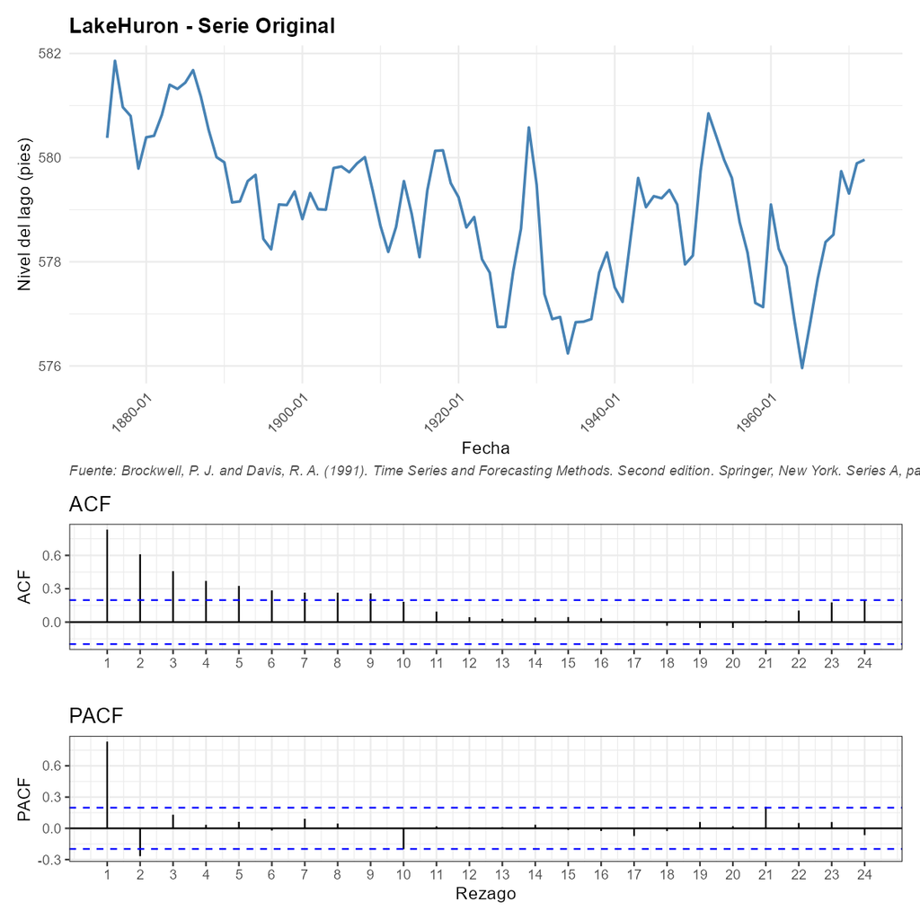

LakeHuron: serie original, ACF y PACF

El nivel del lago desciende en el conjunto del período, pero no en línea recta: alterna tramos de bajada y de recuperación de varios años. Un nivel con una pendiente que cambia con el tiempo es el supuesto del método de Holt, que actualiza por separado el nivel y la pendiente.

**Contraste individual de las autocorrelaciones de la serie**

1. *Hipótesis:* para cada rezago $h = 1, \ldots, 24$, $H_0: \rho_h = 0$ frente a $H_1: \rho_h \neq 0$.
2. *Estadístico:* $r_h = c_h / c_0$, con $c_h = n^{-1}\sum_{t=1}^{n-h}(x_t - \bar x)(x_{t+h} - \bar x)$. Por el resultado de Bartlett, bajo ruido blanco $r_h \approx N(0, 1/n)$, con $n = 98$.
3. *Región de rechazo al 5%:* $|r_h| > z_{0.975}/\sqrt{n} = 1.96/\sqrt{98} = 0.1980$.
4. *Valores observados:* la tabla muestra $r_h$, $z = r_h\sqrt{n}$ y su valor p en los rezagos que sostienen la lectura.
5. *Decisión:* se rechaza $H_0$ en los rezagos 1, 2, 3, 4, 5, 6, 7, 8, 9 y no se rechaza en los demás de los 24 examinados.
6. *Lectura:* las autocorrelaciones son positivas, significativas en los primeros nueve rezagos y decaen despacio: el nivel del lago es muy persistente y cambia de forma gradual, sin volver rápido a un valor fijo.

| Rezago $h$ | $r_h$ | $z$ | Valor p | Decisión |
| --- | --- | --- | --- | --- |
| 1 | 0.8319 | 8.236 | < 0.0001 | Se rechaza |
| 2 | 0.6099 | 6.038 | < 0.0001 | Se rechaza |
| 3 | 0.4583 | 4.536 | < 0.0001 | Se rechaza |
| 5 | 0.3256 | 3.223 | 0.0013 | Se rechaza |
| 9 | 0.2577 | 2.551 | 0.0107 | Se rechaza |
| 10 | 0.1827 | 1.809 | 0.0704 | No se rechaza |

**Prueba de Ljung-Box sobre la serie**

1. *Hipótesis:* $H_0: \rho_1 = \cdots = \rho_{24} = 0$ frente a $H_1$: al menos un $\rho_h \neq 0$ con $h \le 24$.
2. *Estadístico:* $Q_m = T(T+2)\sum_{h=1}^{m} r_h^2/(T-h)$, con $T = 98$ y $m = 24$. Bajo $H_0$, $Q_m \sim \chi^2_{m-p}$, con $p = 0$ parámetros estimados, es decir $\chi^2_{24}$.
3. *Región de rechazo al 5%:* $Q_m > \chi^2_{0.95;\,24} = 36.415$.
4. *Valor observado:* $Q_m = 203.237$, valor p $< 0.0001$.
5. *Decisión:* Se rechaza $H_0$ al 5%.
6. *Lectura:* la dependencia temporal es fuerte, así que el nivel y la dirección recientes del lago son informativos para pronosticar.

### Partición y ajuste

El tramo de validación son las últimas $h = 12$ observaciones y el ajuste usa las primeras 86. Las constantes se eligieron con `optimizar()` sobre la rejilla del producto de $\{0.05, 0.10, \ldots, 0.95\}$ consigo mismo, es decir, 361 combinaciones de $(\alpha, \beta)$.

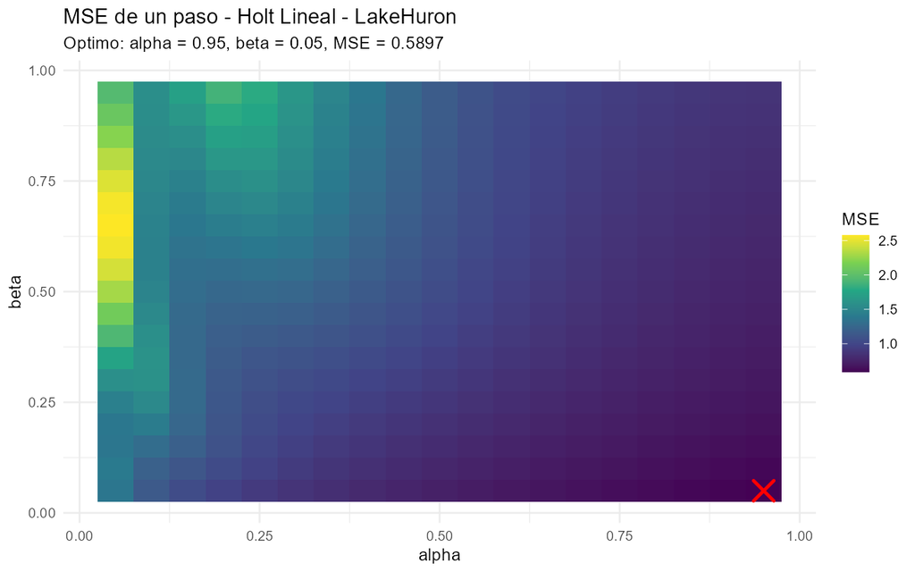

Holt: MSE de un paso sobre la rejilla (alpha, beta)

El óptimo es $\alpha = 0.95$ y $\beta = 0.05$, con MSE de 0.5897, y ambos caen en bordes de la rejilla. En el mapa, el MSE disminuye de forma continua hacia la esquina de $\alpha$ alto y $\beta$ bajo, y los valores más altos, cercanos a 2.6, aparecen con $\alpha = 0.05$. Un $\alpha$ en el borde superior significa que el nivel se actualiza casi por completo con la última observación, de modo que el método se acerca al pronóstico ingenuo; eso indica que la serie no es estacionaria en media, porque no hay un nivel estable hacia el cual volver. Un $\beta$ en el borde inferior significa que la pendiente se actualiza muy poco: el método casi no incorpora tendencia. En conjunto, Holt se comporta aquí como un ingenuo con una pequeña deriva.

### Medidas de precisión

```r
round(rbind(metodo_estimacion    = ej$medidas_in,
            metodo_validacion    = ej$medidas_out,
            referente_validacion = ej$medidas_referente_out), 4)
```

```
                        MSE    MAD   MAPE   MASE
metodo_estimacion    0.5897 0.5983 0.1033 1.0422
metodo_validacion    2.1430 1.2000 0.2078 2.0902
referente_validacion 2.2384 1.2425 0.2151 2.1642
```

En validación, Holt obtiene un MAD de 1.200 pies frente a 1.243 del ingenuo, un error apenas 3.4% menor, con MAPE de 0.21%. Que la diferencia sea tan pequeña es coherente con los parámetros en los bordes: el método es casi el ingenuo. El MASE de 2.09 es mayor que 1 porque en validación se pronostica hasta 12 años adelante, mientras que el MASE se escala con el error de un año al siguiente.

### Validación de errores

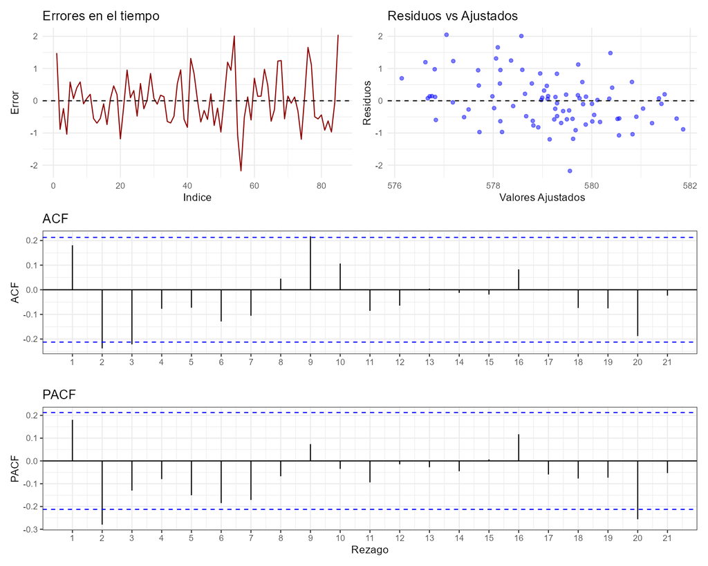

Holt: diagnóstico de los errores

**Contraste individual de las autocorrelaciones de los errores**

1. *Hipótesis:* para cada rezago $h = 1, \ldots, 21$, $H_0: \rho_h = 0$ frente a $H_1: \rho_h \neq 0$.
2. *Estadístico:* $r_h = c_h / c_0$, con $c_h = n^{-1}\sum_{t=1}^{n-h}(x_t - \bar x)(x_{t+h} - \bar x)$. Por el resultado de Bartlett, bajo ruido blanco $r_h \approx N(0, 1/n)$, con $n = 85$.
3. *Región de rechazo al 5%:* $|r_h| > z_{0.975}/\sqrt{n} = 1.96/\sqrt{85} = 0.2126$.
4. *Valores observados:* la tabla muestra $r_h$, $z = r_h\sqrt{n}$ y su valor p en los rezagos que sostienen la lectura.
5. *Decisión:* se rechaza $H_0$ en los rezagos 2, 3, 9 y no se rechaza en los demás de los 21 examinados.
6. *Lectura:* unos pocos rezagos quedan fuera de la banda, sin formar un patrón claro; el primer rezago está dentro de ella.

| Rezago $h$ | $r_h$ | $z$ | Valor p | Decisión |
| --- | --- | --- | --- | --- |
| 1 | 0.1806 | 1.665 | 0.0959 | No se rechaza |
| 2 | -0.2379 | -2.194 | 0.0283 | Se rechaza |
| 3 | -0.2216 | -2.043 | 0.0411 | Se rechaza |
| 9 | 0.2172 | 2.003 | 0.0452 | Se rechaza |

**Prueba t de media cero de los errores** ($N = 85$ errores)

1. *Hipótesis:* $H_0: \mu_e = 0$ frente a $H_1: \mu_e \neq 0$.
2. *Estadístico:* $t = \sqrt{N}\,\bar e / s_e$. Bajo $H_0$, $t \sim t_{N-1} = t_{84}$.
3. *Región de rechazo al 5%:* $|t| > t_{0.975;\,84} = 1.989$.
4. *Valor observado:* $t = 0.049$, valor p $= 0.9607$.
5. *Decisión:* No se rechaza $H_0$ al 5%.
6. *Lectura:* los errores no están sesgados.

**Prueba de Ljung-Box sobre los errores**

1. *Hipótesis:* $H_0: \rho_1 = \cdots = \rho_{21} = 0$ frente a $H_1$: al menos un $\rho_h \neq 0$ con $h \le 21$.
2. *Estadístico:* $Q_m = T(T+2)\sum_{h=1}^{m} r_h^2/(T-h)$, con $T = 85$ y $m = 21$. Bajo $H_0$, $Q_m \sim \chi^2_{m-p}$, con $p = 2$ parámetros estimados, es decir $\chi^2_{19}$.
3. *Región de rechazo al 5%:* $Q_m > \chi^2_{0.95;\,19} = 30.144$.
4. *Valor observado:* $Q_m = 29.153$, valor p $= 0.0636$.
5. *Decisión:* No se rechaza $H_0$ al 5%.
6. *Lectura:* no se rechaza la independencia de los errores al 5%, aunque el valor p está cerca del límite.

**Prueba de Jarque-Bera** ($N = 85$ errores)

1. *Hipótesis:* $H_0$: los errores son normales ($A = 0$ y $K = 3$) frente a $H_1$: no son normales.
2. *Estadístico:* $JB = \frac{N}{6}\left[A^2 + \frac{(K-3)^2}{4}\right]$, con asimetría $A = 0.383$ y curtosis $K = 3.307$. Bajo $H_0$, $JB \sim \chi^2_2$ de forma asintótica.
3. *Región de rechazo al 5%:* $JB > \chi^2_{0.95;\,2} = 5.991$.
4. *Valor observado:* $JB = 2.418$, valor p $= 0.2985$.
5. *Decisión:* No se rechaza $H_0$ al 5%.
6. *Lectura:* los errores son compatibles con una distribución normal.

**Prueba de Durbin-Watson** ($N = 85$ errores)

1. *Hipótesis:* $H_0: \rho_1 = 0$ frente a $H_1: \rho_1 \neq 0$.
2. *Estadístico:* $d = \sum_{t=2}^{N}(e_t - e_{t-1})^2 / \sum_{t=1}^{N} e_t^2 \approx 2(1 - r_1)$. Las cotas $d_L$ y $d_U$ solo aplican a residuos de una regresión; para los errores de un método se usa que, bajo $H_0$, $r_1 \approx N(0, 1/N)$, de modo que $z = (2 - d)\sqrt{N}/2 \approx N(0, 1)$.
3. *Región de rechazo al 5%:* $|z| > 1.96$, equivalente a $d < 1.575$ o $d > 2.425$.
4. *Valor observado:* $d = 1.512$, $z = 2.250$, valor p $= 0.0245$.
5. *Decisión:* Se rechaza $H_0$ al 5%.
6. *Lectura:* la aproximación asintótica lleva a rechazar por poco. Sin embargo, la autocorrelación muestral del primer rezago, $r_1 = 0.181$, queda dentro de la banda de $\pm 0.2126$ y Ljung-Box no rechaza, así que la evidencia de autocorrelación de primer orden es marginal.

### Pronóstico

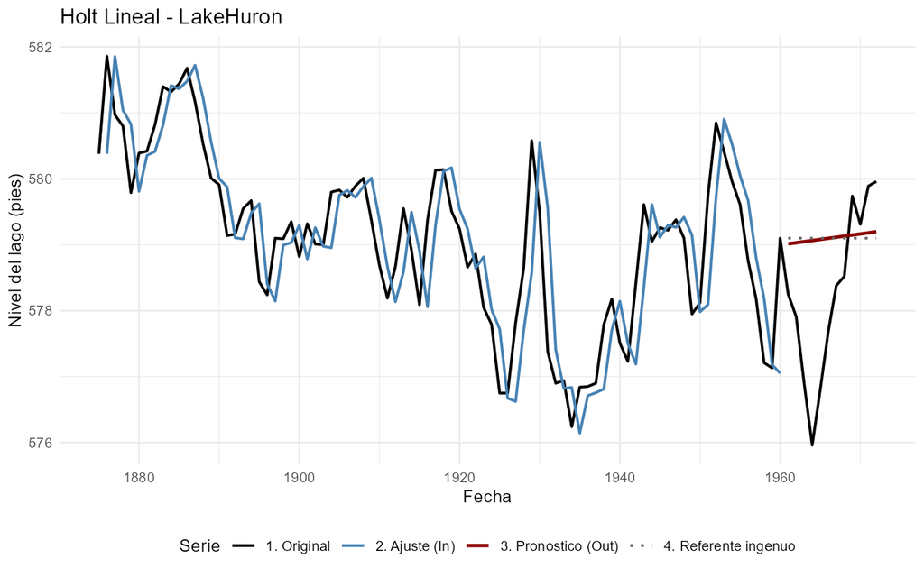

Holt: ajuste y pronóstico sobre el tramo de validación

### Conclusión

Se ajustó el método de Holt con $\alpha = 0.95$ y $\beta = 0.05$, elegidos por `optimizar()` en los bordes de la rejilla. En validación ($h = 12$) su MAD fue 1.200 pies, frente a 1.243 del ingenuo, con MAPE de 0.21%. Los errores cumplen media cero ($t = 0.049$), independencia según Ljung-Box ($Q = 29.15$, valor p $= 0.0636$) y normalidad ($JB = 2.418$), con una evidencia marginal de autocorrelación de primer orden según Durbin-Watson ($d = 1.512$).

### Recomendación

Este pronóstico sirve a quienes administran la navegación y los puertos de los Grandes Lagos, que necesitan anticipar el nivel del agua de los años siguientes. Es razonable hasta los 12 años validados, pero su valor agregado sobre repetir el último nivel observado es muy pequeño. Su límite es que no anticipa los cambios de dirección del nivel del lago: en validación el mayor error absoluto fue de 3.10 pies en un solo año, y la ganancia frente al ingenuo fue de apenas 0.042 pies de MAD.

## 9. Contraejemplo: Media Simple sobre AirPassengers

```r
ejecutar_protocolo("AirPassengers", datasets::AirPassengers,
                   "Box, G. E. P., Jenkins, G. M. and Reinsel, G. C. (1976) Time Series Analysis, Forecasting and Control. Third Edition. Holden-Day. Series G",
                   "Miles de pasajeros", "ajustar_media", "Media Simple (Contraejemplo)",
                   p_params = 0, prefijo = "09")
```

### Descripción de la serie

```r
ej <- resultados$ej09
c(N = ej$N, frecuencia = ej$frecuencia)
```

```
         N frecuencia
       144         12
```

```r
c(inicio = ej$fecha_ini, fin = ej$fecha_fin)
```

```
      inicio          fin
"1949-01-01" "1960-12-01"
```

La serie `AirPassengers` registra el total mensual de pasajeros de aerolíneas internacionales. Fuente: Box, G. E. P., Jenkins, G. M. and Reinsel, G. C. (1976) Time Series Analysis, Forecasting and Control. Third Edition. Holden-Day. Series G. Unidad: miles de pasajeros. Frecuencia mensual, de 01/1949 a 12/1960, con $N = 144$ observaciones.

### Patrón de la serie

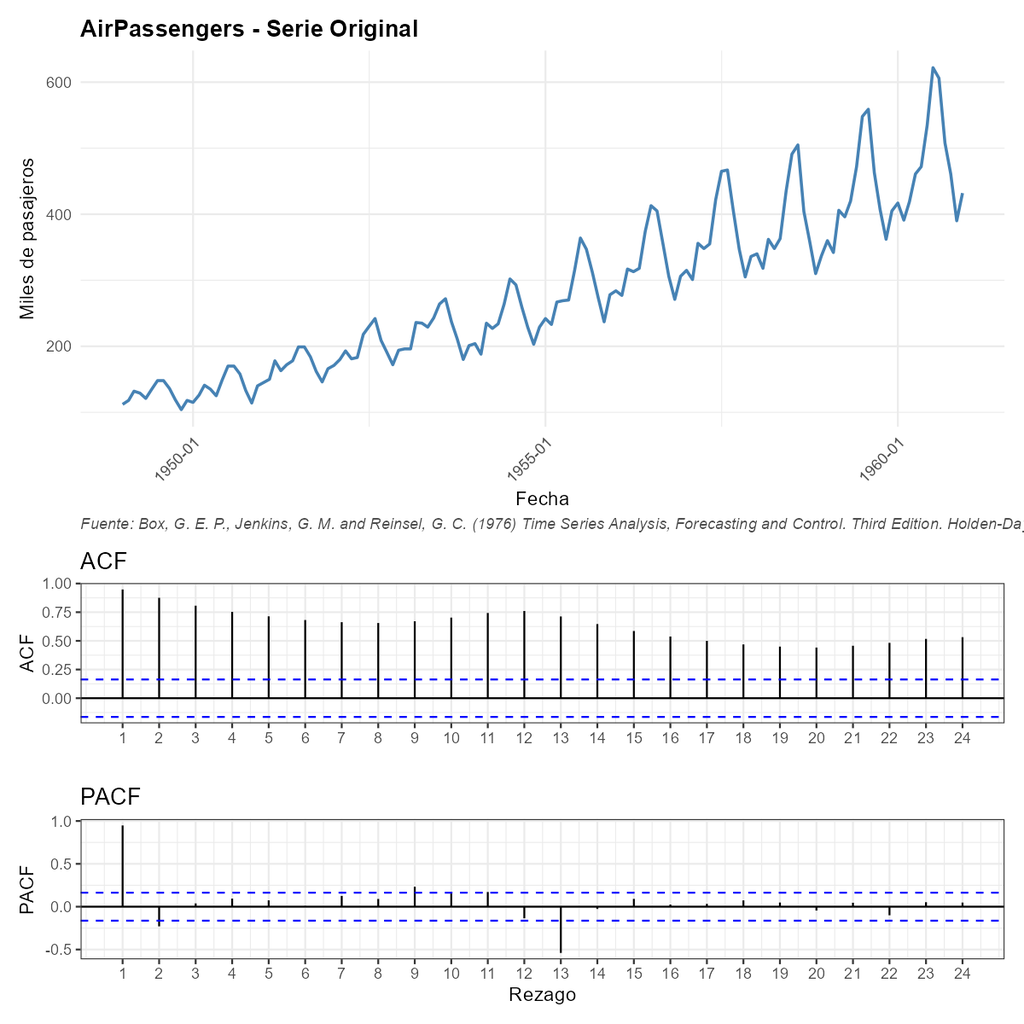

AirPassengers: serie original, ACF y PACF

La serie tiene una tendencia creciente fuerte y una estacionalidad anual cuya amplitud aumenta con el nivel. Ambos rasgos contradicen el supuesto de la media simple, que es un nivel constante. Este ejemplo repite el método del ejemplo 1 sobre una serie inadecuada para mostrar en qué se nota que el método falla.

**Contraste individual de las autocorrelaciones de la serie**

1. *Hipótesis:* para cada rezago $h = 1, \ldots, 24$, $H_0: \rho_h = 0$ frente a $H_1: \rho_h \neq 0$.
2. *Estadístico:* $r_h = c_h / c_0$, con $c_h = n^{-1}\sum_{t=1}^{n-h}(x_t - \bar x)(x_{t+h} - \bar x)$. Por el resultado de Bartlett, bajo ruido blanco $r_h \approx N(0, 1/n)$, con $n = 144$.
3. *Región de rechazo al 5%:* $|r_h| > z_{0.975}/\sqrt{n} = 1.96/\sqrt{144} = 0.1633$.
4. *Valores observados:* la tabla muestra $r_h$, $z = r_h\sqrt{n}$ y su valor p en los rezagos que sostienen la lectura.
5. *Decisión:* se rechaza $H_0$ en los rezagos 1, 2, 3, 4, 5, 6, 7, 8, 9, 10, 11, 12, 13, 14, 15, 16, 17, 18, 19, 20, 21, 22, 23, 24 y no se rechaza en los demás de los 24 examinados.
6. *Lectura:* las 24 autocorrelaciones son significativas y decaen muy despacio, con repuntes en los rezagos 12 y 24: el correlograma combina una tendencia y una estacionalidad anual, exactamente lo contrario de un nivel constante.

| Rezago $h$ | $r_h$ | $z$ | Valor p | Decisión |
| --- | --- | --- | --- | --- |
| 1 | 0.9480 | 11.377 | < 0.0001 | Se rechaza |
| 6 | 0.6817 | 8.181 | < 0.0001 | Se rechaza |
| 11 | 0.7432 | 8.919 | < 0.0001 | Se rechaza |
| 12 | 0.7604 | 9.125 | < 0.0001 | Se rechaza |
| 13 | 0.7127 | 8.552 | < 0.0001 | Se rechaza |
| 24 | 0.5322 | 6.386 | < 0.0001 | Se rechaza |

**Prueba de Ljung-Box sobre la serie**

1. *Hipótesis:* $H_0: \rho_1 = \cdots = \rho_{24} = 0$ frente a $H_1$: al menos un $\rho_h \neq 0$ con $h \le 24$.
2. *Estadístico:* $Q_m = T(T+2)\sum_{h=1}^{m} r_h^2/(T-h)$, con $T = 144$ y $m = 24$. Bajo $H_0$, $Q_m \sim \chi^2_{m-p}$, con $p = 0$ parámetros estimados, es decir $\chi^2_{24}$.
3. *Región de rechazo al 5%:* $Q_m > \chi^2_{0.95;\,24} = 36.415$.
4. *Valor observado:* $Q_m = 1606.084$, valor p $< 0.0001$.
5. *Decisión:* Se rechaza $H_0$ al 5%.
6. *Lectura:* la dependencia temporal es extrema; la serie está muy lejos de ser un nivel constante con ruido.

### Partición y ajuste

La serie es estacional, así que el referente es el ingenuo estacional. El tramo de validación son las últimas $h = 12$ observaciones, un ciclo completo, y el ajuste usa las primeras 132. El pronóstico de la media simple es $\bar Y_T = 262.49$ miles de pasajeros para todos los meses.

### Medidas de precisión

```r
round(rbind(metodo_estimacion    = ej$medidas_in,
            metodo_validacion    = ej$medidas_out,
            referente_validacion = ej$medidas_referente_out), 4)
```

```
                           MSE      MAD    MAPE   MASE
metodo_estimacion    11493.720  83.3505 26.8310 2.7373
metodo_validacion    51196.154 213.6742 43.6215 7.0172
referente_validacion  2571.333  47.8333  9.9875 1.5709
```

En validación, la media simple obtiene un MAD de 213.67 miles de pasajeros, 4.5 veces el 47.83 del ingenuo estacional, con MAPE de 43.62% y MASE de 7.02. El método no supera al referente, y la diferencia es enorme: el pronóstico se queda anclado en el promedio de todo el pasado, muy por debajo de los valores recientes.

### Validación de errores

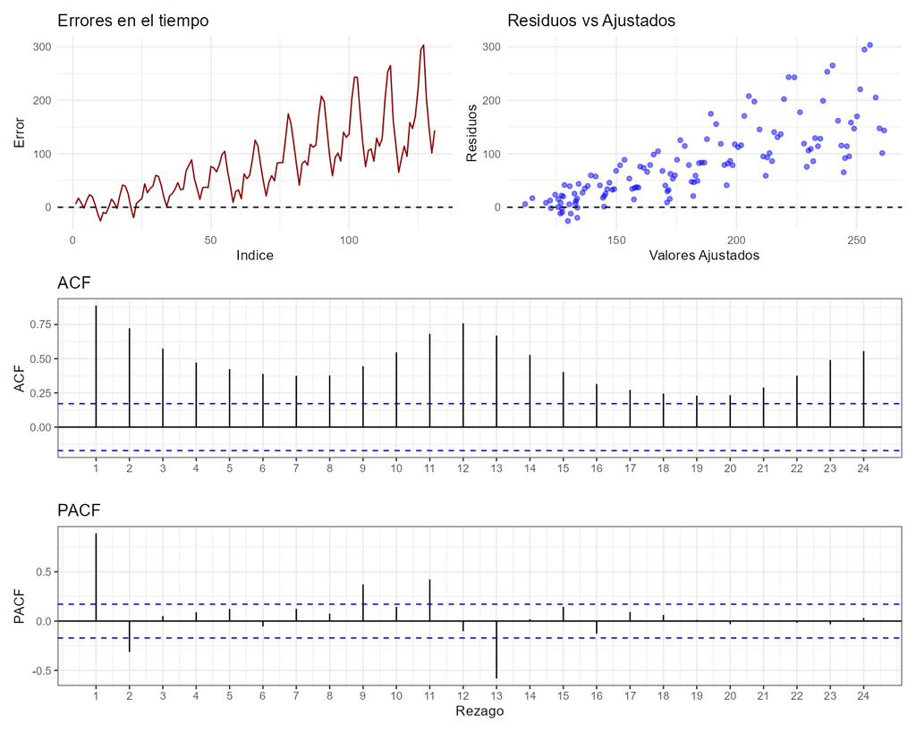

Contraejemplo: diagnóstico de los errores

**Contraste individual de las autocorrelaciones de los errores**

1. *Hipótesis:* para cada rezago $h = 1, \ldots, 24$, $H_0: \rho_h = 0$ frente a $H_1: \rho_h \neq 0$.
2. *Estadístico:* $r_h = c_h / c_0$, con $c_h = n^{-1}\sum_{t=1}^{n-h}(x_t - \bar x)(x_{t+h} - \bar x)$. Por el resultado de Bartlett, bajo ruido blanco $r_h \approx N(0, 1/n)$, con $n = 131$.
3. *Región de rechazo al 5%:* $|r_h| > z_{0.975}/\sqrt{n} = 1.96/\sqrt{131} = 0.1712$.
4. *Valores observados:* la tabla muestra $r_h$, $z = r_h\sqrt{n}$ y su valor p en los rezagos que sostienen la lectura.
5. *Decisión:* se rechaza $H_0$ en los rezagos 1, 2, 3, 4, 5, 6, 7, 8, 9, 10, 11, 12, 13, 14, 15, 16, 17, 18, 19, 20, 21, 22, 23, 24 y no se rechaza en los demás de los 24 examinados.
6. *Lectura:* las 24 autocorrelaciones de los errores son significativas y decaen despacio, con repuntes en los rezagos 12 y 24: los errores heredan íntegras la tendencia y la estacionalidad de la serie. Esta es la huella más clara del fracaso del método en el correlograma.

| Rezago $h$ | $r_h$ | $z$ | Valor p | Decisión |
| --- | --- | --- | --- | --- |
| 1 | 0.8882 | 10.166 | < 0.0001 | Se rechaza |
| 6 | 0.3890 | 4.452 | < 0.0001 | Se rechaza |
| 11 | 0.6812 | 7.797 | < 0.0001 | Se rechaza |
| 12 | 0.7588 | 8.685 | < 0.0001 | Se rechaza |
| 13 | 0.6690 | 7.657 | < 0.0001 | Se rechaza |
| 24 | 0.5557 | 6.361 | < 0.0001 | Se rechaza |

**Prueba t de media cero de los errores** ($N = 131$ errores)

1. *Hipótesis:* $H_0: \mu_e = 0$ frente a $H_1: \mu_e \neq 0$.
2. *Estadístico:* $t = \sqrt{N}\,\bar e / s_e$. Bajo $H_0$, $t \sim t_{N-1} = t_{130}$.
3. *Región de rechazo al 5%:* $|t| > t_{0.975;\,130} = 1.978$.
4. *Valor observado:* $t = 13.568$, valor p $< 0.0001$.
5. *Decisión:* Se rechaza $H_0$ al 5%.
6. *Lectura:* los errores están sesgados: son positivos en promedio, porque la media de todo el pasado va siempre por detrás de una serie que crece.

**Prueba de Ljung-Box sobre los errores**

1. *Hipótesis:* $H_0: \rho_1 = \cdots = \rho_{24} = 0$ frente a $H_1$: al menos un $\rho_h \neq 0$ con $h \le 24$.
2. *Estadístico:* $Q_m = T(T+2)\sum_{h=1}^{m} r_h^2/(T-h)$, con $T = 131$ y $m = 24$. Bajo $H_0$, $Q_m \sim \chi^2_{m-p}$, con $p = 0$ parámetros estimados, es decir $\chi^2_{24}$.
3. *Región de rechazo al 5%:* $Q_m > \chi^2_{0.95;\,24} = 36.415$.
4. *Valor observado:* $Q_m = 869.616$, valor p $< 0.0001$.
5. *Decisión:* Se rechaza $H_0$ al 5%.
6. *Lectura:* los errores están lejos de ser ruido blanco; el método no captura nada de la estructura de la serie.

**Prueba de Jarque-Bera** ($N = 131$ errores)

1. *Hipótesis:* $H_0$: los errores son normales ($A = 0$ y $K = 3$) frente a $H_1$: no son normales.
2. *Estadístico:* $JB = \frac{N}{6}\left[A^2 + \frac{(K-3)^2}{4}\right]$, con asimetría $A = 0.979$ y curtosis $K = 3.687$. Bajo $H_0$, $JB \sim \chi^2_2$ de forma asintótica.
3. *Región de rechazo al 5%:* $JB > \chi^2_{0.95;\,2} = 5.991$.
4. *Valor observado:* $JB = 23.482$, valor p $< 0.0001$.
5. *Decisión:* Se rechaza $H_0$ al 5%.
6. *Lectura:* los errores no son normales: tienen asimetría positiva, porque crecen a medida que la serie se aleja de su promedio histórico.

**Prueba de Durbin-Watson** ($N = 131$ errores)

1. *Hipótesis:* $H_0: \rho_1 = 0$ frente a $H_1: \rho_1 \neq 0$.
2. *Estadístico:* $d = \sum_{t=2}^{N}(e_t - e_{t-1})^2 / \sum_{t=1}^{N} e_t^2 \approx 2(1 - r_1)$. Las cotas $d_L$ y $d_U$ solo aplican a residuos de una regresión; para los errores de un método se usa que, bajo $H_0$, $r_1 \approx N(0, 1/N)$, de modo que $z = (2 - d)\sqrt{N}/2 \approx N(0, 1)$.
3. *Región de rechazo al 5%:* $|z| > 1.96$, equivalente a $d < 1.658$ o $d > 2.342$.
4. *Valor observado:* $d = 0.086$, $z = 10.952$, valor p $< 0.0001$.
5. *Decisión:* Se rechaza $H_0$ al 5%.
6. *Lectura:* hay autocorrelación positiva de primer orden casi total, con $r_1 \approx 0.957$.

### Pronóstico

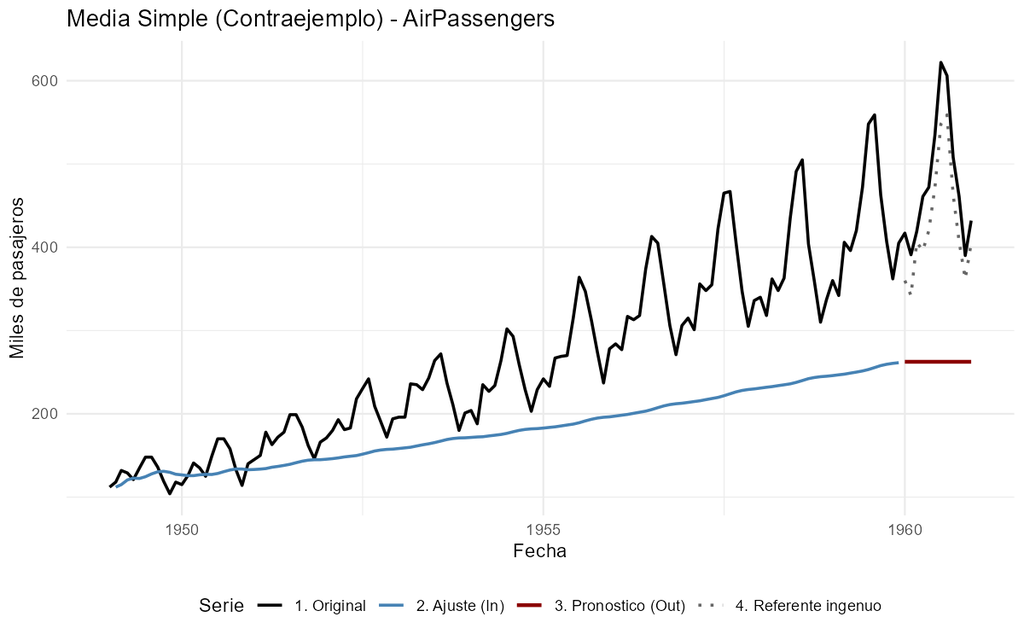

Contraejemplo: ajuste y pronóstico sobre el tramo de validación

### Conclusión

Se aplicó la media simple a una serie con tendencia y estacionalidad, con pronóstico constante de 262.49 miles de pasajeros. En validación ($h = 12$) su MAD fue 213.67, frente a 47.83 del ingenuo estacional, con MASE de 7.02. La validación de errores falla en todas las pruebas: sesgo ($t = 13.57$), autocorrelación según Ljung-Box ($Q = 869.6$, valor p $< 0.0001$) y Durbin-Watson ($d = 0.086$), y no normalidad ($JB = 23.48$). El correlograma de los errores, con las 24 autocorrelaciones fuera de la banda y repuntes en los rezagos 12 y 24, muestra que la estructura de la serie pasó intacta a los errores.

### Recomendación

Este pronóstico no le sirve a nadie para planear: una aerolínea que lo usara subestimaría la demanda de cada mes del año siguiente. No hay un horizonte razonable, porque el error aparece desde el primer mes: en validación el error absoluto fue de 154.5 miles de pasajeros en el primer mes y llegó a 359.5 en el peor, frente a un pronóstico de 262.5. El límite del método es su supuesto de nivel constante: cuando la serie tiene tendencia y estacionalidad, la media simple no tiene cómo seguirlas.

## Resumen de los ejemplos

| Ejemplo | Método | Serie | Parámetros | MAD validación | MAD referente | MASE | ¿Supera al referente? |
| --- | --- | --- | --- | --- | --- | --- | --- |
| 1 | Media simple | `discoveries` | Ninguno | 1.955 | 2.417 | 0.919 | Sí |
| 2 | Media móvil | `discoveries` | $k = 9$ | 1.250 | 2.417 | 0.588 | Sí |
| 3 | Suavizamiento exponencial simple | `Nile` | $\alpha = 0.24$ | 107.117 | 111.000 | 0.806 | Sí |
| 4 | Doble media móvil | `WWWusage` | $k = 2$ | 6.083 | 33.917 | 1.368 | Sí |
| 5 | Tendencia lineal | `austres` | $\hat\beta_0 = 12963$, $\hat\beta_1 = 50.707$ | 210.080 | 322.042 | 3.974 | Sí |
| 6 | Tendencia cuadrática | `airmiles` | $\hat\beta_0 = 1420.1$, $\hat\beta_1 = -473.93$, $\hat\beta_2 = 74.329$ | 1408.887 | 5254.500 | 1.205 | Sí |
| 7 | Tendencia exponencial | `JohnsonJohnson` | $\hat a = -0.69684$, $\hat\theta = 0.042769$ | 1.883 | 3.428 | 3.586 | Sí |
| 8 | Holt lineal | `LakeHuron` | $\alpha = 0.95$, $\beta = 0.05$ | 1.200 | 1.243 | 2.090 | Sí |
| 9 | Media simple (contraejemplo) | `AirPassengers` | Ninguno | 213.674 | 47.833 | 7.017 | No |

Los ocho métodos superan a su referente en el tramo de validación, cada uno sobre una serie cuyo patrón corresponde a su supuesto, mientras que el contraejemplo lo pierde por un margen amplio. Las mayores ventajas aparecen donde la serie tiene tendencia (doble media móvil, tendencias lineal, cuadrática y exponencial), porque el ingenuo congela el último valor y no sigue el crecimiento. En Nile y LakeHuron la ventaja es pequeña: son series sin tendencia definida en las que el último valor ya es un buen pronóstico, y en el caso de Holt los parámetros óptimos en los bordes de la rejilla lo acercan al propio ingenuo.

## Bloques de verificación

Antes de usar las funciones propias en los ejemplos se verificó que reproducen los resultados de R y las identidades de las notas. La verificación usa una serie simulada de ruido blanco ($n = 100$, semilla 2026) y compara:

- la ACF muestral de `acf_muestral()` contra `acf(plot = FALSE)`, reportando la máxima diferencia absoluta, que debe ser menor que $10^{-12}$;
- el estadístico $Q_m$ de `ljung_box()` contra `Box.test(type = "Ljung-Box")`;
- el suavizamiento exponencial simple en su forma de corrección del error, $\hat Y_{t+1} = \hat Y_t + \alpha e_t$, contra su forma de promedio ponderado, $\hat Y_{t+1} = \sum_{j=0}^{t-2}\alpha(1-\alpha)^j Y_{t-j} + (1-\alpha)^{t-1}Y_1$;
- los coeficientes de las tres tendencias, estimados con las ecuaciones normales, contra `lm()`;
- las ecuaciones de Holt contra su forma de corrección del error, $L_t = L_{t-1} + \hat T_{t-1} + \alpha e_t$ y $\hat T_t = \hat T_{t-1} + \alpha\beta e_t$.

```
====================================================================
BLOQUES DE VERIFICACION
====================================================================
- ACF maxima diferencia absoluta: 5.551115e-17 | Menor que 1e-12: TRUE
- Ljung-Box Qm diferencia absoluta: 7.105427e-15
- SES coincide (correccion de error vs promedio ponderado): TRUE
- Tendencia lineal vs lm(): TRUE
- Tendencia cuadratica vs lm(): TRUE
- Tendencia exponencial (sobre ln Y) vs lm(): TRUE
- Holt coincide nivel: TRUE
- Holt coincide pendiente: TRUE
====================================================================
```

Todas las comparaciones coinciden: las diferencias de la ACF y de Ljung-Box son del orden del error de redondeo de la máquina, y las demás identidades se cumplen exactamente. Esto respalda que las cifras de los ocho ejemplos provienen de implementaciones correctas.